[figure not shown]

Servicio Local de Educación Pública

[figure not shown]

Escudo comunal

San Miguel

🏛️ Informe comunal · Red educativa

Comuna de San Miguel

SLEP Santa Rosa

Director ejecutivo

Luis Echeverría Donaire

Actualización

05-10-2026

Territorio

San Miguel

[🌐 slepsantarosa.gob.cl](https://slepsantarosa.gob.cl)[👥 ¿Quiénes somos?](https://slepsantarosa.gob.cl/quienes-somos/)[📰 Noticias](https://slepsantarosa.gob.cl/noticias/)

📍

Dirección

Llano Subercaseaux 3629  
San Miguel, SantiagoAbrir Google Maps ↗

🕘

Horario de atención

Lunes a viernes  
9:00 a 13:00 hrs.

✉️

Contacto general

contacto@slepsantarosa.gob.cl

📨

Oficina de partes

oficinapartes@slepsantarosa.gob.cl

**🗺️ Apertura territorial:** La siguiente sección es el mapa comunal integrado con zoom inicial reforzado, para ubicar la red antes del análisis temático.

🔎 Zoom inicial comunal

🏛

Municipalidad y autoridades

Municipalidad de San Miguel

Autoridades comunales 2024 - 2028 y enlaces institucionales de referencia

[🌐 Sitio web](https://web.sanmiguel.cl/)

Datos institucionales

🏠

Dirección municipal

Av. Departamental 3079, San Miguel

🌐

Sitio web

https://web.sanmiguel.cl/

🏫

Pdte. comisión educación

Por confirmar con municipalidad

Alcalde / alcaldesa

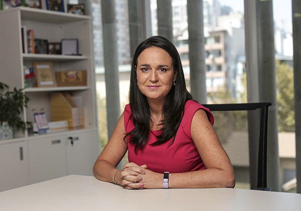

Carol Bown Tapia

(UDI)

👥 Concejo municipal

8 concejales/as registrados

Gabriel Zúñiga

(PS)

Carla Santana

(PC)

Luis Sanhueza

(RN)

Claudio Escobar

(Ind.)

Viviana Llambías

(FA)

Eva Merino

(REP)

Felipe Guevara

(RN)

Claudia Rojas

(UDI)

🗺️ Red comunal

Mapa integrado de establecimientos y municipio · Comuna de San Miguel

Esta visualización ubica en un solo mapa a **escuelas y liceos**, **jardines infantiles** y la **municipalidad**. Al hacer clic en cada punto se abre una ficha breve con foco en matrícula y asistencia.

📍 16 puntos visibles

🏫 Escuelas y liceos

10

Asistencia ref.: Agosto 2026

🌱 Jardines infantiles

5

Corte ref.: Agosto 2026

📚 Matrícula total red

4.408

escuelas + jardines

🧭 Asistencia referencial

E/L 84.1% · JI 67.6%

promedio ponderado por matrícula

**Lectura del mapa:** 🏫 azul para escuelas y liceos, 🌱 lila para jardines infantiles y 🏛️ ámbar para la municipalidad. Los popups territoriales privilegian la lectura de matrícula y asistencia, manteniendo una referencia resumida de oferta educativa.  
Nota: el punto municipal se ubicó como referencia territorial cuando la base no trajo coordenadas explícitas.

[interactive chart not shown]

# 🗺️ Red Territorial

🗺️

Lectura territorial comunal

La portada ya deja el contexto institucional y comunal. Ahora el mapa abre la lectura espacial de **escuelas, liceos, jardines infantiles y municipio** para entrar después al detalle temático del informe.

📊

Panorama General · Comuna de San Miguel

Datos actualizados a Agosto 2026

🔄

**Cobertura del panorama comunal** 🏫 Escuelas y liceos 🌱 Jardines infantiles

En esta sección se mostrará la información consolidada de las escuelas, liceos y jardines infantiles de la comuna de San Miguel, integrando ambas redes en una lectura territorial con la paleta institucional del SLEP Santa Rosa.

Red educativa total

(Escuelas/Liceos + Jardines Infantiles)

📊 Matrícula Total

4.408

estudiantes + párvulos

🏫 Establecimientos

15

escuelas, liceos y jardines

📈 Promedio por EE

294

matrícula por establecimiento

🏫 Escuelas y Liceos

3.977

10 establecimientos · 90.2% del total

🌱 Jardines Infantiles

431

5 jardines · 9.8% del total

🏫 Escuelas y Liceos

(Agosto 2026)

👨‍🎓 Matrícula EyL

3.977

estudiantes activos

🏫 Establecimientos

10

escuelas y liceos

🗓️ Asistencia Promedio

84.1%

días asistidos/matriculados

🌱 Jardines Infantiles

(Agosto 2026)

👶 Matrícula JI

431

párvulos activos

🌿 Jardines

5

unidades del servicio

📅 Asistencia Promedio

67.6%

días asistidos/matriculados

Composición de matrícula por nivel

Escuelas, liceos y jardines infantiles de la comuna

Jardines Infantiles

🌱

Nivel Medio

264

párvulos

6%

5 jardines

Jardines Infantiles

🍼

Sala Cuna

167

párvulos

3.8%

5 jardines

Escuelas y Liceos

📚

Básica Niños

2.205

estudiantes

50%

7 establecimientos

Escuelas y Liceos

⚛️

Media HC Jóvenes

970

estudiantes

22%

2 establecimientos

Escuelas y Liceos

🏫

Parvularia

289

estudiantes

6.6%

5 establecimientos

Escuelas y Liceos

📖

Media HC Adultos

263

estudiantes

6%

2 establecimientos

Escuelas y Liceos

🧩

Ed. Especial

178

estudiantes

4%

1 establecimientos

Escuelas y Liceos

🌙

Básica Adultos

72

estudiantes

1.6%

1 establecimientos

**📅 Corte vigente:** Agosto 2026. La matrícula presentada en esta tabla proviene de la **tabla consolidada de matrícula y asistencia**.

### 🏫 Establecimientos de Comuna de San Miguel

10 establecimientos con matrícula activa

| Logo | Establecimiento | Director(a) | Comuna | Matrícula | Niveles | IVE EE 2026 | IVE Com. 2026 | SNCAE |
| --- | --- | --- | --- | --- | --- | --- | --- | --- |
|  | Liceo Andres Bello RBD 9406 | Jorge Oscar Muñoz Lopez | San Miguel | 643 | 📚 Básica Niños · ⚛️ Media HC Jóvenes | – | – | Sin certificación |
|  | Escuela Territorio Antartico RBD 9415 | Tomás Enrique Huerta Calderon | San Miguel | 628 | 🏫 Parvularia · 📚 Básica Niños | – | – | Sin certificación |
|  | Escuela Llano Subercaseaux RBD 9426 | María Ignacia Duran Echeverria | San Miguel | 553 | 🏫 Parvularia · 📚 Básica Niños | – | – | Sin certificación |
|  | Liceo Betsabe Hormazabal De Alarcon RBD 9405 | Raúl Mauricio Navarro Gomez | San Miguel | 508 | 📚 Básica Niños · ⚛️ Media HC Jóvenes | – | – | Sin certificación |
|  | Escuela General Basica Santa Fe RBD 9413 | José Luis Echeverría Isamit | San Miguel | 416 | 🏫 Parvularia · 📚 Básica Niños | – | – | Sin certificación |
|  | Escuela Basica Pablo Neruda RBD 9433 | Emiliano Hernán Octavio Cabrera Barra | San Miguel | 362 | 🏫 Parvularia · 📚 Básica Niños | – | – | 🌿 Básico |
|  | Escuela Villa San Miguel RBD 9431 | Rodrigo Hernan Reyes Garrido | San Miguel | 354 | 🏫 Parvularia · 📚 Básica Niños | – | – | 🌿 Excelencia |
|  | Inst. Reg. Educ Adultos San Miguel RBD 9460 | Grecia Del Carmen Opazo Leon | San Miguel | 185 | 📖 Media HC Adultos | – | – | Sin certificación |
|  | Escuela Especial Los Cedros Del Libano RBD 9444 | Romina Silvana Tasso Ramirez | San Miguel | 178 | 🧩 Ed. Especial | – | – | Sin certificación |
|  | Esc. Esp. De Adultos Hugo Morales Bizama RBD 9461 | Gladys Rosa Guardia Saéz | San Miguel | 150 | 🌙 Básica Adultos · 📖 Media HC Adultos | – | – | Sin certificación |

### 🌱 Jardines Infantiles de Comuna de San Miguel

5 jardines filtrados por comuna

**📍 Fuente y filtro:** tabla de jardines del informe 04, filtrada para San Miguel. La matrícula corresponde al **último corte disponible** (Agosto 2026). Se muestra además la **directora** y los **niveles ofertados**.

| Logo | Jardín Infantil | Directora | Matrícula | Niveles |
| --- | --- | --- | --- | --- |
|  | Jardin Infantil Santa Fe RBD 13130004 | Pamela Alejandra Peña Águila | 100 | 👶 Sala Cuna · 🧒 Nivel Medio |
|  | Jardin Infantil Villa San Miguel RBD 13130003 | Katherine Carolina San Martin Benavides | 96 | 👶 Sala Cuna · 🧒 Nivel Medio |
|  | Jardin Infantil Andres Bello RBD 13130006 | Rosana Loreto Olguin Valenzuela / Elena Alejandra Tike Riquelme | 92 | 👶 Sala Cuna · 🧒 Nivel Medio |
|  | Jardin Infantil Llano Subercaseaux RBD 13130008 | Jeannette Elena Zavala Aravena | 88 | 👶 Sala Cuna · 🧒 Nivel Medio |
|  | Jardin Infantil Territorio Antartico RBD 13130007 | Flavia Magdalena Fuentes Montecinos | 55 | 👶 Sala Cuna · 🧒 Nivel Medio |

📊

Datos complementarios al desempeño académico

Indicadores de contexto escolar

SNCAE

Sistema Nacional de Certificación Ambiental

Ministerio de Medio Ambiente

Indicador institucional que muestra si el establecimiento participa en el sistema de certificación ambiental y el **nivel alcanzado** . Su lectura es cualitativa: permite distinguir el grado de avance en educación ambiental, gestión sustentable y trabajo con la comunidad.

Cómo leerlo en la ficha Sin certificación o nivel alcanzado

Participación Voluntaria

Tipo de dato Cualitativo

Básico Medio Excelencia

IVE-JUNAEB

Índice de Vulnerabilidad Escolar

JUNAEB

Indicador que estima el porcentaje de estudiantes en situación de **vulnerabilidad socioeducativa** . Se expresa entre 0% y 100%: a mayor valor, mayor concentración de estudiantes con prioridad social. En esta edición se presenta el **IVE SINAE 2026 del establecimiento** junto con su **referencia comunal 2026** .

Escala 0% — 100%

Cómo leerlo en la ficha Mayor porcentaje = mayor vulnerabilidad; comparar con referencia comunal

Versiones IVE establecimiento 2026 + IVE comunal 2026

IVE EE 2026 IVE Comunal 2026 Serie metodológica vigente

SNED

Sistema Nacional de Evaluación del Desempeño

Desempeño de excelencia

Indicador que identifica establecimientos con **desempeño de excelencia** dentro de grupos comparables. En la ficha se interpreta de forma binaria: el establecimiento **obtuvo o no obtuvo SNED** en el proceso vigente.

Cómo leerlo en la ficha Sí obtuvo o no obtuvo SNED

Periodicidad Proceso bianual

Comparación Entre establecimientos semejantes

Tipo de dato Binario

Resultado binario Desempeño de excelencia Comparación entre pares

# 🌿 Certificación Ambiental SNCAE

# 📈 IVE SINAE 2026 y referencia comunal

#### 🌿 Certificación Ambiental SNCAE

Con Certificación

2

(20% del total)

Sin Certificación

8

##### 📋 Establecimientos con Certificación SNCAE

| Logo | RBD | Establecimiento | Comuna | Nivel SNCAE |
| --- | --- | --- | --- | --- |
|  | 9431 | Escuela Villa San Miguel | San Miguel | Excelencia |
|  | 9433 | Escuela Basica Pablo Neruda | San Miguel | Básico |

#### 📈 IVE SINAE 2026 y referencia comunal

IVE promedio EE

–

0 establecimientos con dato

IVE comunal 2026

–

0 comunas

IVE EE sobre 80

0

0% de los establecimientos con dato

Sobre ref. comunal

0

0% de los EE comparables

##### 🏫 IVE establecimiento 2026

| Tramo | N° EE | % |
| --- | --- | --- |
| 0-20% | 0 | 0,0% |
| 21-40% | 0 | 0,0% |
| 41-60% | 0 | 0,0% |
| 61-80% | 0 | 0,0% |
| 81-100% | 0 | 0,0% |

##### 🏙️ Referencia comunal 2026

| Comuna | IVE comunal | N° EE |
| --- | --- | --- |
| Sin referencias comunales disponibles. |  |  |

La referencia comunal se informa con la base 2026 vigente para cada territorio. Esta sección reemplaza la lectura histórica basada en aperturas metodológicas anteriores.

# 🏆 SNED

### 🏆 Sistema Nacional de Evaluación del Desempeño (SNED) - Comuna de San Miguel

El **SNED** es un instrumento de política pública del Estado de Chile que evalúa y reconoce el desempeño de los establecimientos educacionales en función de múltiples indicadores de calidad y equidad educativa. Considera dimensiones como la efectividad, superación, iniciativa, mejoramiento, igualdad e integración. Los establecimientos con mejor desempeño relativo acceden a la **Subvención por Desempeño de Excelencia**.

Participan en SNED

10

de 10 establecimientos

🏆 Seleccionados

2

Subvención de Excelencia

No Seleccionados

8

Índice SNED Promedio

67.57

Promedio SLEP

##### 🏆 Establecimientos Seleccionados - Subvención de Excelencia

RBD 9444

Escuela Especial Los Cedros Del Libano

San Miguel

Índice

95.29

RBD 9433

Escuela Basica Pablo Neruda

San Miguel

Índice

69.5

##### 📊 Desglose de Factores - Promedio SLEP

Efectividad37%

Mide el nivel de resultados educativos alcanzados, considerando el desempeño en pruebas SIMCE.

38.9%

📋 9 establecimientos con datos

Superación28%

Evalúa los avances en resultados educativos a lo largo del tiempo.

63.5%

📋 9 establecimientos con datos

Iniciativa6%

Considera la capacidad para innovar y fortalecer el proyecto educativo.

90.8%

📋 10 establecimientos con datos

Mejoramiento2%

Evalúa el cumplimiento normativo y funcionamiento institucional.

99.9%

📋 10 establecimientos con datos

Integración5%

Evalúa la participación de la comunidad educativa.

76.5%

📋 10 establecimientos con datos

Igualdad22%

Mide el grado de inclusión e igualdad de oportunidades.

96.1%

📋 10 establecimientos con datos

# 🧑‍🎓 Concentración alumnos prioritarios

### 📊 Concentración · Alumnado Prioritario

2025 · Promedio Comuna

44.6%

2026 · Promedio Comuna

43.5%

Variación Promedio

↓ 1.1 pp

Comparación 2026 vs 2025

| Logo | RBD | Establecimiento | 2025 Concentración | 2026 Concentración | Variación |
| --- | --- | --- | --- | --- | --- |
|  | 9461 | ESC. ESP. DE ADULTOS HUGO MORALES BIZAMA 📅 Marzo Mantienen ACAP | 60% | 60% | → 0,0 pp |
|  | 9413 | ESCUELA GENERAL BASICA SANTA FE 📅 Marzo Sin ACAP 2025-2026 | 52.8% | 49.4% | ↓ 3.4 pp |
|  | 9444 | ESCUELA ESPECIAL LOS CEDROS DEL LIBANO 📅 Marzo Sin ACAP 2025-2026 | 46.6% | 48.8% | ↑ +2.2 pp |
|  | 9406 | LICEO ANDRES BELLO 📅 Marzo Sin ACAP 2025-2026 | 45.4% | 45.4% | ↓ 0 pp |
|  | 9460 | INST. REG. EDUC ADULTOS SAN MIGUEL 📅 Marzo Sin ACAP 2025-2026 | 28.5% | 44.8% | ↑ +16.4 pp |
|  | 9405 | LICEO BETSABE HORMAZABAL DE ALARCON 📅 Marzo Sin ACAP 2025-2026 | 40.6% | 39.7% | ↓ 0.9 pp |
|  | 9426 | ESCUELA LLANO SUBERCASEAUX 📅 Marzo Sin ACAP 2025-2026 | 42.8% | 37.5% | ↓ 5.2 pp |
|  | 9415 | ESCUELA TERRITORIO ANTARTICO 📅 Marzo Sin ACAP 2025-2026 | 42.5% | 37.3% | ↓ 5.2 pp |
|  | 9433 | ESCUELA BASICA MUNICIPAL PABLO NERUDA 📅 Marzo Sin ACAP 2025-2026 | 41.7% | 37% | ↓ 4.7 pp |
|  | 9431 | ESCUELA VILLA SAN MIGUEL 📅 Marzo Sin ACAP 2025-2026 | 45.1% | 34.9% | ↓ 10.2 pp |

ℹ️ Lectura de la tabla:↑ Aumento en concentración de alumnado prioritario | ↓ Disminución en concentración | 2025 vs 2026

# 🏫 Resumen Matrícula

📊 Sección

Detalle de Matrícula · Comuna de San Miguel

Escuelas, liceos y jardines infantiles de la red comunal

📍 Vista comunal integrada

La **matrícula** corresponde al registro de niños, niñas y estudiantes vigentes en cada establecimiento del territorio. En esta sección se presentan de manera complementaria los detalles de matrícula de **escuelas y liceos** y de **jardines infantiles** de la comuna de San Miguel. La lectura integrada permite comparar volumen, distribución por establecimiento y composición por nivel educativo dentro de la red comunal del **SLEP Santa Rosa**.

🏫Escuelas y Liceos

▸Fuente principal: **CEM · SIGE · Mineduc** vía DEP.

▸Corte de referencia: **Agosto 2026**.

▸Se desagrega por establecimiento, género, nacionalidad, pueblos originarios, grado y nivel educativo.

🌱Jardines Infantiles

▸Fuente principal: **Gesparvu / GPW JUNJI** consolidada en el informe comunal.

▸Corte de referencia: **Agosto 2026**.

▸Se muestra matrícula por jardín, distribución por Sala Cuna, Nivel Medio y Transición, junto con asistencia y capacidad cuando existen datos.

🧭Cómo leer esta sección

▸Primero se presenta el **detalle de escuelas y liceos** con su composición de matrícula y variables sociodemográficas.

▸Luego se presenta el **detalle de jardines infantiles**, con foco en volumen de párvulos, niveles ofertados y desempeño del corte vigente.

📊 Panorama consolidado

Matrícula de escuelas y liceos

Información agregada de los establecimientos de la comuna de San Miguel. **Fuente:** Centro de Estudios del Mineduc (CEM).

📅 Datos a: Agosto 2026🔄 Actualización mensual

👥

##### Resumen matrícula

Total estudiantes

3.977

📅 Agosto 2026

👥

🏫 Establecimientos activos**10**

🌍 Estudiantes extranjeros**1.381 (34,7%)**

🌎

##### Composición

Género

👦 Masculino**2.329** (58,6%)

👧 Femenino**1.648** (41,4%)

Origen

🇨🇱 Chilenos**2.596** (65,3%)

🌍 Extranjeros**1.381** (34,7%)

🌿

##### Pueblos originarios

🌿 Mapuche**65** (1,6%)

🌐 Otra etnia**4** (0,1%)

🏺 Diaguita**2** (0,1%)

☀️ Aymara**1** (0,0%)

🗺️

##### Nacionalidades

🇨🇱 Chilena**3.139** (78,9%)

🇻🇪 Venezolana**385** (9,7%)

🌐 Otra**183** (4,6%)

🇨🇴 Colombiana**58** (1,5%)

🇵🇪 Peruana**33** (0,8%)

🇪🇨 Ecuatoriana**22** (0,6%)

🇧🇴 Boliviana**10** (0,3%)

🇦🇷 Argentina**5** (0,1%)

🇧🇷 Brasilera**5** (0,1%)

🇨🇺 Cubana**2** (0,1%)

🇫🇷 Francesa**2** (0,1%)

🇭🇹 Haitiana**2** (0,1%)

🇨🇳 China**1** (0,0%)

🇮🇹 Italiana**1** (0,0%)

📊

##### Matrícula por nivel

🏫 Parvularia**289** (7,3%)

📚 Básica Niños**2.205** (55,4%)

⚛️ Media HC Jóvenes**970** (24,4%)

🧩 Ed. Especial**178** (4,5%)

🌙 Básica Adultos**72** (1,8%)

📖 Media HC Adultos**263** (6,6%)

🛠️

##### Matrícula TP por especialidad

Sin especialidades TP registradas en el período.

🎓

##### Detalle por curso

Distribución total de estudiantes por curso o grado en el último período disponible.

Pre-kínder**134** (3,4%)

Kínder**155** (3,9%)

1° Básico**214** (5,4%)

2° Básico**242** (6,1%)

3° Básico**263** (6,6%)

4° Básico**259** (6,5%)

5° Básico**279** (7,0%)

6° Básico**299** (7,5%)

7° Básico**335** (8,4%)

8° Básico**402** (10,1%)

1° Medio**298** (7,5%)

2° Medio**240** (6,0%)

3° Medio**219** (5,5%)

4° Medio**213** (5,4%)

Nivel de Transición 1**9** (0,2%)

Nivel de Transición 2**15** (0,4%)

Laboral 1**66** (1,7%)

Nivel Básico 2 (5° y 6° Básico)**32** (0,8%)

Nivel Básico 3 (7° y 8° Básico)**40** (1,0%)

1° Nivel (Adultos)**107** (2,7%)

2° Nivel (Adultos)**156** (3,9%)

##### 🏫 Detalle de Matrícula por Establecimiento

Desglose completo de 10 establecimientos con matrícula activa.

| Logo | Establecimiento | 📊 Matrícula Total | 👥 Género 👨 M | 👥 Género 👩 F | 🌎 Nacionalidad 🏔️ Chi | 🌎 Nacionalidad 🌍 Ext | 🌎 Nacionalidad 📄 Nac | 🌿 Pueblos Orig. N° |
| --- | --- | --- | --- | --- | --- | --- | --- | --- |
|  | Liceo Andres Bello RBD 9406 | 643 16,2% | 643 | 0 | 571 | 72 (11,2%) | 0 | 16 |
|  | Escuela Territorio Antartico RBD 9415 | 628 15,8% | 333 | 295 | 353 | 275 (43,8%) | 0 | 5 |
|  | Escuela Llano Subercaseaux RBD 9426 | 553 13,9% | 301 | 252 | 339 | 214 (38,7%) | 0 | 8 |
|  | Liceo Betsabe Hormazabal De Alarcon RBD 9405 | 508 12,8% | 257 | 251 | 239 | 269 (53,0%) | 0 | 9 |
|  | Escuela General Basica Santa Fe RBD 9413 | 416 10,5% | 226 | 190 | 210 | 206 (49,5%) | 0 | 12 |
|  | Escuela Basica Pablo Neruda RBD 9433 | 362 9,1% | 177 | 185 | 228 | 134 (37,0%) | 0 | 5 |
|  | Escuela Villa San Miguel RBD 9431 | 354 8,9% | 180 | 174 | 221 | 133 (37,6%) | 0 | 3 |
|  | Inst. Reg. Educ Adultos San Miguel RBD 9460 | 185 4,7% | 115 | 70 | 153 | 32 (17,3%) | 0 | 4 |
|  | Escuela Especial Los Cedros Del Libano RBD 9444 | 178 4,5% | 97 | 81 | 144 | 34 (19,1%) | 0 | 4 |
|  | Esc. Esp. De Adultos Hugo Morales Bizama RBD 9461 | 150 3,8% | 0 | 150 | 138 | 12 (8,0%) | 0 | 6 (4,0%) |
| TOTAL COMUNA |  | 3.977 | 2.329 | 1.648 | 2.596 | 1.381 | 0 | 72 |

👶

Jardines Infantiles

Detalle de Matrícula de Jardines — Comuna de San Miguel

Gesparvu / GPW JUNJI · Corte vigente: Agosto 2026

5 jardines filtrados

📅 Corte

Agosto 2026

👶 Matrícula del corte

431

párvulos activos

🏡 Jardines con matrícula

5

unidades con movimiento

🚻 Matrícula por género

🧭 Asistencia agregada

67.2%

días asistidos / matriculados

Sala Cuna

167

párvulos

38.7%

5 jardines

Nivel Medio

264

párvulos

61.3%

5 jardines

##### 🏫 Detalle de Matrícula por Jardín Infantil

Desglose completo de 5 jardines con matrícula activa en el corte seleccionado.

[output not shown]

# 🕰️ Evolución Matricula

🕰️ Sección

Evolución Histórica de la Matrícula

CEM · SIGE · Serie histórica anual

📈 Tendencia Histórica

La **evolución histórica de matrícula** muestra cómo ha variado el número de estudiantes inscritos a lo largo de los años en los establecimientos de la comuna de San Miguel. Esta tendencia es un indicador estructural del territorio: refleja cambios demográficos, migraciones, decisiones de familias sobre el tipo de educación y el impacto de políticas públicas como la **Ley SEP (Subvención Escolar Preferencial)** o las campañas de permanencia escolar. Un descenso sostenido de matrícula en el sector público puede indicar un proceso de **“fuga” hacia el sector subvencionado**, lo que requiere análisis territorial.

📊Cómo leer la tendencia

▸Se compara el **promedio mensual de matrícula de cada año**, resumiendo la serie consolidada disponible.

▸**Variación % interanual:** caídas de más de 3% en un año son señal de alerta para la gestión territorial.

🌐Factores que afectan la matrícula

▸**Demográficos:** tasas de natalidad, migraciones internas, densificación urbana.

▸**Elección de familias:** oferta de establecimientos privados subvencionados en el territorio.

## 📈 Evolución Histórica de la Matrícula de Escuelas y Liceos - Comuna de San Miguel

#### 📊 Panel de Análisis Histórico

Visualización del **promedio anual de matrícula** construido desde la serie mensual consolidada. **Fuente:** Centro de Estudios del Mineduc (CEM).

📅 Último Año

2026

👨‍🎓 Matrícula Promedio

3.942

Promedio mensual del año

📊 Var. Interanual

-0.6%

🏫 Estab. Promedio

10

6 meses considerados

[interactive chart not shown]

##### 🏫 Matrícula Promedio por Establecimiento y Año

Comparativa anual de matrícula promedio por establecimiento. **Nota:** La variación porcentual (Var.) se calcula comparando el promedio de matrícula del año **2026** respecto al promedio del año **2025**.

| Logo | RBD | Establecimiento | Comuna | 2016 | 2017 | 2018 | 2019 | 2022 | 2023 | 2024 | 2025 | 2026 | Var. % |
| --- | --- | --- | --- | --- | --- | --- | --- | --- | --- | --- | --- | --- | --- |
|  | 9406 | Liceo Andres Bello | San Miguel | 652 | 657 | 672 | 649 | 615 | 629 | 612 | 589 | 637 | +8.1% |
|  | 9415 | Escuela Territorio Antartico | San Miguel | 506 | 555 | 622 | 719 | 658 | 660 | 650 | 648 | 623 | -3.9% |
|  | 9426 | Escuela Llano Subercaseaux | San Miguel | 475 | 498 | 524 | 522 | 569 | 578 | 586 | 582 | 554 | -4.8% |
|  | 9405 | Liceo Betsabe Hormazabal De Alarcon | San Miguel | 422 | 339 | 359 | 449 | 489 | 488 | 480 | 504 | 502 | -0.4% |
|  | 9413 | Escuela General Basica Santa Fe | San Miguel | 258 | 260 | 331 | 375 | 408 | 418 | 424 | 424 | 410 | -3.3% |
|  | 9433 | Escuela Basica Pablo Neruda | San Miguel | 359 | 376 | 385 | 358 | 365 | 366 | 366 | 363 | 364 | +0.3% |
|  | 9431 | Escuela Villa San Miguel | San Miguel | 387 | 404 | 429 | 436 | 426 | 424 | 358 | 363 | 354 | -2.5% |
|  | 9444 | Escuela Especial Los Cedros Del Libano | San Miguel | 156 | 154 | 148 | 149 | 150 | 151 | 163 | 170 | 176 | +3.5% |
|  | 9460 | Inst. Reg. Educ Adultos San Miguel | San Miguel | 223 | 237 | 257 | 249 | 190 | 194 | 174 | 164 | 170 | +3.7% |
|  | 9461 | Esc. Esp. De Adultos Hugo Morales Bizama | San Miguel | 229 | 244 | 267 | 193 | 168 | 202 | 164 | 157 | 152 | -3.2% |

##### 📈 Top 10 Mayor Crecimiento (2025 → 2026)

1

Liceo Andres Bello

RBD 9406 • San Miguel

+8.1%

2

Inst. Reg. Educ Adultos San Miguel

RBD 9460 • San Miguel

+3.7%

3

Escuela Especial Los Cedros Del Libano

RBD 9444 • San Miguel

+3.5%

4

Escuela Basica Pablo Neruda

RBD 9433 • San Miguel

+0.3%

5

Liceo Betsabe Hormazabal De Alarcon

RBD 9405 • San Miguel

+-0.4%

6

Escuela Villa San Miguel

RBD 9431 • San Miguel

+-2.5%

7

Esc. Esp. De Adultos Hugo Morales Bizama

RBD 9461 • San Miguel

+-3.2%

8

Escuela General Basica Santa Fe

RBD 9413 • San Miguel

+-3.3%

9

Escuela Territorio Antartico

RBD 9415 • San Miguel

+-3.9%

10

Escuela Llano Subercaseaux

RBD 9426 • San Miguel

+-4.8%

##### 📉 Top 10 Mayor Decrecimiento (2025 → 2026)

1

Escuela Llano Subercaseaux

RBD 9426 • San Miguel

-4.8%

2

Escuela Territorio Antartico

RBD 9415 • San Miguel

-3.9%

3

Escuela General Basica Santa Fe

RBD 9413 • San Miguel

-3.3%

4

Esc. Esp. De Adultos Hugo Morales Bizama

RBD 9461 • San Miguel

-3.2%

5

Escuela Villa San Miguel

RBD 9431 • San Miguel

-2.5%

6

Liceo Betsabe Hormazabal De Alarcon

RBD 9405 • San Miguel

-0.4%

7

Escuela Basica Pablo Neruda

RBD 9433 • San Miguel

0.3%

8

Escuela Especial Los Cedros Del Libano

RBD 9444 • San Miguel

3.5%

9

Inst. Reg. Educ Adultos San Miguel

RBD 9460 • San Miguel

3.7%

10

Liceo Andres Bello

RBD 9406 • San Miguel

8.1%

🌱

Jardines Infantiles

Parte 2 · Jardines Infantiles — Evolución Histórica de Matrícula · Comuna de San Miguel

Gesparvu / GPW JUNJI · serie histórica comunal de párvulos matriculados

5 jardines filtrados

📊 Lectura histórica de jardines infantiles

Esta segunda parte presenta la **evolución histórica agregada de la matrícula en jardines infantiles** de la comuna de San Miguel. Se observan los cambios en el volumen de párvulos matriculados, la cantidad de jardines con registros vigentes y la composición promedio por nivel ofertado. **Fuente:** Gesparvu / GPW JUNJI.

📅 Último período

Agosto 2026

👶 Matrícula actual

431

párvulos matriculados

📈 Var. interanual

+0,2%

comparación con igual mes del año previo

🏡 Jardines observados

5

mejor registro: Diciembre 2025

Últimos 12 períodos observados · Jardines infantiles

| Período | Matrícula | Jardines | Var. período |
| --- | --- | --- | --- |
| Julio 2025 | 425 | 5 | +0,0% |
| Agosto 2025 | 430 | 5 | +1,2% |
| Septiembre 2025 | 432 | 5 | +0,5% |
| Octubre 2025 | 429 | 5 | -0,7% |
| Noviembre 2025 | 432 | 5 | +0,7% |
| Diciembre 2025 | 432 | 5 | +0,0% |
| Marzo 2026 | 389 | 5 | -10,0% |
| Abril 2026 | 399 | 5 | +2,6% |
| Mayo 2026 | 407 | 5 | +2,0% |
| Junio 2026 | 415 | 5 | +2,0% |
| Julio 2026 | 422 | 5 | +1,7% |
| Agosto 2026 | 431 | 5 | +2,1% |

# 🏫 Resumen asistencia

🧭 Sección

Evolución Histórica de Asistencia

SIGE · Ley SAE · Ausentismo crónico

📅 Ley SAE

La **asistencia escolar** mide qué porcentaje de los días hábiles en que un estudiante tenía matrícula vigente, efectivamente asistió al establecimiento. Se calcula como: **días asistidos ÷ días con matrícula activa × 100**. La **Ley SAE (Sistema de Alerta Escolar)** obliga a los establecimientos a reportar y gestionar el ausentismo. El **ausentismo crónico** se define como la inasistencia a más del 20% de los días hábiles y es un predictor fuerte de rezago, repitencia y abandono escolar.

⚠️Umbrales de alerta

▸**≥ 90%:** asistencia regular. Meta mínima del sistema.

▸**80–89%:** riesgo moderado. Requiere seguimiento individual.

▸**< 80%:** ausentismo crónico. Activación de protocolo SAE y reporte a la DEP.

💡Uso para la gestión

▸La tendencia histórica permite identificar si el ausentismo es **estructural** (se repite año a año) o **coyuntural** (asociado a eventos puntuales).

▸Útil para planificar recursos de **convivencia escolar, trabajo social y psicología** focalizado en establecimientos críticos.

📘 Panorama consolidado

Asistencia de escuelas y liceos

Información agregada de los establecimientos de la comuna de San Miguel. **Fuente:** Centro de Estudios del Mineduc (CEM). El cálculo se basa en días asistidos sobre días con matrícula activa.

📅 Datos a: Agosto 2026🎯 Meta referencial: 90%

📘

##### Resumen asistencia

Asistencia total

84,1%

📅 Agosto 2026

📘

👨‍🎓 Matrícula de referencia**3.977**

🏫 Establecimientos con dato**10**

🌎

##### Composición

Género

👦 Masculino**85,0%** · N 2.329

👧 Femenino**82,8%** · N 1.648

Origen

🇨🇱 Chilenos**81,8%** · N 2.596

🌍 Extranjeros**88,3%** · N 1.381

🌿

##### Pueblos originarios

🌿 Mapuche**83,1%** · N 65

🌐 Otra etnia**85,7%** · N 4

🏺 Diaguita**76,2%** · N 2

☀️ Aymara**100,0%** · N 1

🌐

##### Nacionalidades

🇨🇱 Chilena**83,4%** · N 3.139

🇻🇪 Venezolana**88,2%** · N 385

🌐 Otra**88,5%** · N 183

🇨🇴 Colombiana**83,1%** · N 58

🇵🇪 Peruana**83,4%** · N 33

🇪🇨 Ecuatoriana**80,9%** · N 22

🇧🇴 Boliviana**91,0%** · N 10

🇦🇷 Argentina**80,0%** · N 5

🇧🇷 Brasilera**85,7%** · N 5

🇨🇺 Cubana**95,2%** · N 2

🇫🇷 Francesa**85,7%** · N 2

🇭🇹 Haitiana**83,3%** · N 2

🇨🇳 China**90,5%** · N 1

🇮🇹 Italiana**90,5%** · N 1

📊

##### Asistencia por nivel

🏫 Parvularia**81,0%** · N 289

📚 Básica Niños**88,6%** · N 2.205

⚛️ Media HC Jóvenes**87,0%** · N 970

🧩 Ed. Especial**66,6%** · N 178

🌙 Básica Adultos**64,9%** · N 72

📖 Media HC Adultos**55,4%** · N 263

🛠️

##### Asistencia TP por especialidad

Sin especialidades TP registradas en el período.

🏫

##### Detalle por curso

Asistencia promedio del último período disponible por curso o grado.

Pre-kínder**79,8%** · N 134

Kínder**81,9%** · N 155

1° Básico**85,9%** · N 214

2° Básico**84,3%** · N 242

3° Básico**89,8%** · N 263

4° Básico**88,4%** · N 259

5° Básico**87,7%** · N 279

6° Básico**88,4%** · N 299

7° Básico**88,5%** · N 335

8° Básico**86,9%** · N 402

1° Medio**88,4%** · N 298

2° Medio**87,2%** · N 240

3° Medio**86,1%** · N 219

4° Medio**85,6%** · N 213

Nivel de Transición 1**67,2%** · N 9

Nivel de Transición 2**63,8%** · N 15

Laboral 1**72,7%** · N 66

Nivel Básico 2 (5° y 6° Básico)**67,5%** · N 32

Nivel Básico 3 (7° y 8° Básico)**62,9%** · N 40

1° Nivel (Adultos)**55,8%** · N 107

2° Nivel (Adultos)**55,1%** · N 156

##### 🏫 Detalle de Asistencia por Establecimiento

Desglose completo de 10 establecimientos con datos de asistencia en el último período disponible.

| Logo | Establecimiento | Comuna | 📊 Asistencia Total | 👥 Género 👨 M | 👥 Género 👩 F | 🌎 Nacionalidad 🏔️ Chi | 🌎 Nacionalidad 🌍 Ext | 🌎 Nacionalidad 📄 Nac | 👨‍🎓 N N° |
| --- | --- | --- | --- | --- | --- | --- | --- | --- | --- |
|  | Liceo Andres Bello RBD 9406 | San Miguel | 87,4% | 87,4% | – | 87,0% | 90,5% | – | 643 |
|  | Escuela Territorio Antartico RBD 9415 | San Miguel | 88,5% | 88,4% | 88,6% | 85,7% | 92,1% | – | 628 |
|  | Escuela Llano Subercaseaux RBD 9426 | San Miguel | 87,2% | 86,9% | 87,6% | 85,9% | 89,4% | – | 553 |
|  | Liceo Betsabe Hormazabal De Alarcon RBD 9405 | San Miguel | 86,4% | 86,8% | 86,1% | 83,1% | 89,3% | – | 508 |
|  | Escuela General Basica Santa Fe RBD 9413 | San Miguel | 89,6% | 88,6% | 90,9% | 88,5% | 90,7% | – | 416 |
|  | Escuela Basica Pablo Neruda RBD 9433 | San Miguel | 88,3% | 88,8% | 87,8% | 88,4% | 88,1% | – | 362 |
|  | Escuela Villa San Miguel RBD 9431 | San Miguel | 84,7% | 84,4% | 85,1% | 82,2% | 88,8% | – | 354 |
|  | Inst. Reg. Educ Adultos San Miguel RBD 9460 | San Miguel | 52,7% | 52,3% | 53,3% | 53,4% | 49,1% | – | 185 |
|  | Escuela Especial Los Cedros Del Libano RBD 9444 | San Miguel | 66,6% | 70,5% | 61,8% | 67,4% | 63,0% | – | 178 |
|  | Esc. Esp. De Adultos Hugo Morales Bizama RBD 9461 | San Miguel | 63,3% | – | 63,3% | 62,5% | 72,6% | – | 150 |
| TOTAL COMUNA |  |  | 84,1% | 85,0% | 82,8% | 81,8% | 88,3% | – | 3.977 |

# 🧭 Evolucion Asistencia

## 📊 Evolución Histórica de la Asistencia de Escuelas y Liceos - Comuna de San Miguel

#### 📈 Panel de Análisis de Asistencia

Visualización de la evolución del porcentaje de asistencia. **Fuente:** Centro de Estudios del Mineduc (CEM).

📋 **Nota:** Asistencia calculada sobre días matriculados del estudiante.

📅 Último Período

Agosto 2026

📊 Asistencia Actual

84.1%

Estado: En riesgo

📈 Var. Interanual

+2.5 pp

🏫 Establecimientos

10

Umbrales de Asistencia:🟢 ≥90% Óptima🟡 85-89% Aceptable🟠 80-84% En riesgo🔴 <80% Crítica

[interactive chart not shown]

##### 🏫 Asistencia Promedio por Establecimiento y Año

Comparativa anual de asistencia promedio por establecimiento. **Nota:** La variación (Var.) se expresa en **puntos porcentuales (pp)** y compara el promedio de asistencia del año **2026** respecto al año **2025**.

| Logo | RBD | Establecimiento | Comuna | 2016 | 2017 | 2018 | 2019 | 2022 | 2023 | 2024 | 2025 | 2026 | Var. (pp) |
| --- | --- | --- | --- | --- | --- | --- | --- | --- | --- | --- | --- | --- | --- |
|  | 9413 | Escuela General Basica Santa Fe | San Miguel | 88.3% | 87.1% | 88.3% | 88.1% | 86.7% | 85.6% | 85.3% | 86.3% | 88.5% | +2.2 pp |
|  | 9433 | Escuela Basica Pablo Neruda | San Miguel | 90.3% | 90.1% | 91.1% | 89.5% | 85.3% | 86.4% | 87.3% | 88.2% | 87.4% | -0.8 pp |
|  | 9426 | Escuela Llano Subercaseaux | San Miguel | 86.7% | 89% | 89.9% | 82.1% | 85.8% | 83.8% | 85.9% | 85.6% | 86.9% | +1.3 pp |
|  | 9415 | Escuela Territorio Antartico | San Miguel | 82% | 81.7% | 85.1% | 80.2% | 84.4% | 86% | 85.7% | 86.3% | 86.5% | +0.2 pp |
|  | 9431 | Escuela Villa San Miguel | San Miguel | 84.2% | 85.5% | 85% | 82.7% | 84.7% | 80.4% | 82.6% | 84.2% | 85.1% | +0.9 pp |
|  | 9406 | Liceo Andres Bello | San Miguel | 80.1% | 84.5% | 85.7% | 74.9% | 85.9% | 81.4% | 79.7% | 82.3% | 84.6% | +2.3 pp |
|  | 9405 | Liceo Betsabe Hormazabal De Alarcon | San Miguel | 82.1% | 77.8% | 83.1% | 75.9% | 85% | 84.5% | 86.5% | 83.7% | 84.2% | +0.5 pp |
|  | 9444 | Escuela Especial Los Cedros Del Libano | San Miguel | 80.2% | 78.8% | 80.1% | 82.3% | 74.7% | 84.2% | 80.6% | 73.1% | 70.3% | -2.8 pp |
|  | 9460 | Inst. Reg. Educ Adultos San Miguel | San Miguel | 76.5% | 74.4% | 67.1% | 56.6% | 43.8% | 49.5% | 50.1% | 51.8% | 52.5% | +0.7 pp |
|  | 9461 | Esc. Esp. De Adultos Hugo Morales Bizama | San Miguel | 98.7% | 98.7% | 98.7% | 80.7% | 11.8% | 39.2% | 52.3% | 58.1% | 49.4% | -8.7 pp |

##### 📈 Top 10 Mayor Mejora en Asistencia (2025 → 2026)

1

Liceo Andres Bello

RBD 9406 • San Miguel

+2.3 pp

Actual: 84.6%

2

Escuela General Basica Santa Fe

RBD 9413 • San Miguel

+2.2 pp

Actual: 88.5%

3

Escuela Llano Subercaseaux

RBD 9426 • San Miguel

+1.3 pp

Actual: 86.9%

4

Escuela Villa San Miguel

RBD 9431 • San Miguel

+0.9 pp

Actual: 85.1%

5

Inst. Reg. Educ Adultos San Miguel

RBD 9460 • San Miguel

+0.7 pp

Actual: 52.5%

6

Liceo Betsabe Hormazabal De Alarcon

RBD 9405 • San Miguel

+0.5 pp

Actual: 84.2%

7

Escuela Territorio Antartico

RBD 9415 • San Miguel

+0.2 pp

Actual: 86.5%

8

Escuela Basica Pablo Neruda

RBD 9433 • San Miguel

+-0.8 pp

Actual: 87.4%

9

Escuela Especial Los Cedros Del Libano

RBD 9444 • San Miguel

+-2.8 pp

Actual: 70.3%

10

Esc. Esp. De Adultos Hugo Morales Bizama

RBD 9461 • San Miguel

+-8.7 pp

Actual: 49.4%

##### 📉 Top 10 Mayor Disminución en Asistencia (2025 → 2026)

1

Esc. Esp. De Adultos Hugo Morales Bizama

RBD 9461 • San Miguel

-8.7 pp

Actual: 49.4%

2

Escuela Especial Los Cedros Del Libano

RBD 9444 • San Miguel

-2.8 pp

Actual: 70.3%

3

Escuela Basica Pablo Neruda

RBD 9433 • San Miguel

-0.8 pp

Actual: 87.4%

4

Escuela Territorio Antartico

RBD 9415 • San Miguel

0.2 pp

Actual: 86.5%

5

Liceo Betsabe Hormazabal De Alarcon

RBD 9405 • San Miguel

0.5 pp

Actual: 84.2%

6

Inst. Reg. Educ Adultos San Miguel

RBD 9460 • San Miguel

0.7 pp

Actual: 52.5%

7

Escuela Villa San Miguel

RBD 9431 • San Miguel

0.9 pp

Actual: 85.1%

8

Escuela Llano Subercaseaux

RBD 9426 • San Miguel

1.3 pp

Actual: 86.9%

9

Escuela General Basica Santa Fe

RBD 9413 • San Miguel

2.2 pp

Actual: 88.5%

10

Liceo Andres Bello

RBD 9406 • San Miguel

2.3 pp

Actual: 84.6%

🧭

Jardines Infantiles

Parte 2 · Jardines Infantiles — Evolución Histórica de Asistencia · Comuna de San Miguel

Gesparvu / GPW JUNJI · días asistidos sobre días matriculados

5 jardines filtrados

📊 Lectura histórica de asistencia en jardines

Esta segunda parte replica la lectura histórica para **jardines infantiles**, mostrando la evolución comunal de la asistencia promedio, la cantidad de jardines con registros y la trayectoria anual del indicador. **Fuente:** Gesparvu / GPW JUNJI.

📅 Último período

Agosto 2026

🧭 Asistencia actual

67.6%

En alerta

📈 Var. interanual

+4,7 pp

comparación con igual mes del año previo

🏡 Jardines observados

5

mejor registro: Abril 2026

🚦 Umbrales de seguimiento para jardines:🟢 ≥75% Meta🟠 60% a 74,9% Alerta🔴 <60% Crítica

Últimos 12 períodos observados · Jardines infantiles

| Período | Asistencia | Jardines | Matrícula | Var. período |
| --- | --- | --- | --- | --- |
| Julio 2025 | 66.8% | 5 | 425 | +9,4 pp |
| Agosto 2025 | 62.9% | 5 | 430 | -4,0 pp |
| Septiembre 2025 | 69.1% | 5 | 432 | +6,2 pp |
| Octubre 2025 | 71.7% | 5 | 429 | +2,7 pp |
| Noviembre 2025 | 74.5% | 5 | 432 | +2,8 pp |
| Diciembre 2025 | 66.2% | 5 | 432 | -8,3 pp |
| Marzo 2026 | 62.4% | 5 | 389 | -3,8 pp |
| Abril 2026 | 76% | 5 | 399 | +13,6 pp |
| Mayo 2026 | 74.9% | 5 | 407 | -1,1 pp |
| Junio 2026 | 68.2% | 5 | 415 | -6,7 pp |
| Julio 2026 | 61.8% | 5 | 422 | -6,5 pp |
| Agosto 2026 | 67.6% | 5 | 431 | +5,8 pp |

# 💼 Ocupación establecimientos

💼 Sección

Ocupación de Establecimientos

SIGE · Capacidad instalada · Cupos disponibles

🏢 Capacidad Instalada

La **tasa de ocupación** de un establecimiento expresa qué porcentaje de su **capacidad instalada** está siendo efectivamente utilizada por estudiantes matriculados. Se calcula como: **matrícula vigente ÷ capacidad de atención × 100**. La capacidad de atención es el número máximo de estudiantes que puede recibir el establecimiento según su infraestructura y las normas del Mineduc. Establecimientos con baja ocupación generan **costos fijos elevados por alumno**, lo cual afecta la eficiencia del gasto público. En esta vista comunal se distinguen dos lecturas: **escuelas y liceos** con base en **capacidad SAE reportada**, y **jardines infantiles** con base en **cupos Gesparvu**, por lo que ambas se muestran por separado.

📐Rangos de ocupación

▸**≥ 85%:** uso eficiente de la infraestructura. Situación ideal.

▸**60–84%:** infraestructura subutilizada. Analizar causas (déficit de oferta, problemas de imagen).

▸**< 60%:** establecimiento en riesgo de cierre o fusión. Requiere intervención estratégica en el territorio.

💡Uso para la planificación

▸Permite identificar establecimientos con **cupos disponibles** para derivar matrículas desde sectores saturados.

▸Base para decisiones de **inversión en infraestructura, fusión de cursos o racionalización de la red** educativa comunal.

💼

Jardines Infantiles

Parte 2 · Jardines Infantiles — Ocupación de Jardines · Comuna de San Miguel

Cruce entre matrícula vigente y cupos Gesparvu

5 jardines filtrados

💼 Jardines Infantiles

Cómo se calcula la ocupación de jardines

Gesparvu (GPW) · JUNJI · estructura de cursos vigente

📐 Cupos Gesparvu

📏 Cómo se leen los cupos

Los cupos de los jardines infantiles se leen desde la **estructura de cursos Gesparvu (GPW) de JUNJI**, consolidada en la base **bd_estructura_cursos_jisc**. Esta referencia organiza la oferta vigente por nivel, grado y grupo para transparentar los cupos efectivos disponibles en cada unidad educativa.

📐 Superficie mínima

🍼 Sala Cuna

2,5 m2 por párvulo

🌱 Nivel Medio y Transición

1,1 m2 por párvulo

🎯 Cómo leerla

La ocupación se interpreta como matrícula sobre cupos Gesparvu. Esta vista permite distinguir jardines con holgura, alta ocupación y sobrecupo para priorizar gestión de vacantes y ajustes de oferta.

Ocupación global

90.2%

matrícula total sobre capacidad total

Alta ocupación

2

jardines entre 90% y 99,9%

Sobrecupo

jardines sobre 100% de cupos

Con holgura

0

jardines bajo 75% de ocupación

🌱 Parte 2 · Jardines Infantiles — Detalle de Ocupación

Se listan todos los jardines filtrados para la comuna. **Balance positivo** indica vacantes disponibles y **balance negativo** indica sobrecupo.

5 jardines con cupos

| Logo | Jardín infantil | Cupos | Matrícula | Balance | Ocupación | Estado |
| --- | --- | --- | --- | --- | --- | --- |
|  | Jardin Infantil Llano Subercaseaux San Miguel · RBD 13130008 | 88 | 88 | +0 vacantes | 100% 88 / 88 | 🔴 SOBRECUPO |
|  | Jardin Infantil Territorio Antartico San Miguel · RBD 13130007 | 56 | 55 | +1 vacantes | 98.2% 55 / 56 | 🟠 ALTA |
|  | Jardin Infantil Andres Bello San Miguel · RBD 13130006 | 94 | 92 | +2 vacantes | 97.9% 92 / 94 | 🟠 ALTA |
|  | Jardin Infantil Santa Fe San Miguel · RBD 13130004 | 120 | 100 | +20 vacantes | 83.3% 100 / 120 | 🔵 MEDIA |
|  | Jardin Infantil Villa San Miguel San Miguel · RBD 13130003 | 120 | 96 | +24 vacantes | 80% 96 / 120 | 🔵 MEDIA |

# 🔄 Análisis de Retiros y Movilidad Estudiantil Comunal

📉 Movilidad Estudiantil · Visión Comunal

Análisis de Retiros y Movilidad — Comuna de San Miguel

🔄 Actualización Mensual

Consolida todos los movimientos de estudiantes de los establecimientos de la comuna de San Miguel, cruzando la base interna con el **SIGE** para determinar continuidad educativa. Se distingue el **destino de cada retiro** según la dependencia del establecimiento receptor.

🚪 Tipos de Movimiento

🔄 Colisión / Cambio interno (mismo RBD)

🏫 Cambio a EE del SLEP

🚪 Cambio a EE externo al SLEP

⚠️ Sin matrícula vigente en SIGE

📍 Dependencias de Destino

🏫 Mismo SLEP · 🔀 Otro SLEP

🏛️ Particular Subvencionado

💳 Particular Pagado

📋 Administración Delegada

⚠️ Sin Matrícula

📉 Retiros y Movilidad Estudiantil — Comuna de San Miguel

Seleccionar año de visualización

Año por defecto: 2026

📌 Datos visualizados: Año 2026 · último mes actualizado: Agosto

🚪 Total Retiros

463

Año 2026 · último mes actualizado: Agosto

✅ Con Continuidad

166

35.9% con matrícula

⚠️ Sin Matrícula SIGE

220

47.5% alerta

⏳ Pendiente SIGE

77

sin confirmación al corte

🔄 Cambios Internos

33

mismo colegio

🏫 EE con Retiros

10

establecimientos

⚠️ **47.5% de los estudiantes retirados** (220) no aparece con matrícula vigente en SIGE — posible riesgo de abandono escolar.

📅 Retiros por Mes · corte Agosto 2026

Mar52

Abr105

May112

Jun60

Jul65

Ago69

📍 Dependencia de Destino

⚠️ Sin Matrícula128

🏛️ Part. Subvencionado120

⚠️ Sin matrícula vigente92

🏫 Mismo SLEP62

🔀 Otro SLEP55

📋 Adm. Delegada5

💳 Part. Pagado1

📋 Tipo de Movimiento

⚠️ Sin matrícula220

🚪 Cambio a EE externo181

🔄 Colisión / Cambio interno33

🏫 Cambio a EE del SLEP29

📌 Datos visualizados: Año 2025 · último mes actualizado: Diciembre

🚪 Total Retiros

612

Año 2025 · último mes actualizado: Diciembre

✅ Con Continuidad

350

57.2% con matrícula

⚠️ Sin Matrícula SIGE

262

42.8% alerta

⏳ Pendiente SIGE

0

sin confirmación al corte

🔄 Cambios Internos

33

mismo colegio

🏫 EE con Retiros

10

establecimientos

⚠️ **42.8% de los estudiantes retirados** (262) no aparece con matrícula vigente en SIGE — posible riesgo de abandono escolar.

📅 Retiros por Mes · corte Diciembre 2025

Mar123

Abr101

May70

Jun40

Jul95

Ago51

Sep57

Oct45

Nov20

Dic10

📍 Dependencia de Destino

⚠️ Sin matrícula vigente262

🏛️ Part. Subvencionado163

🔀 Otro SLEP102

🏫 Mismo SLEP72

📋 Adm. Delegada7

💳 Part. Pagado6

📋 Tipo de Movimiento

🚪 Cambio a EE externo278

⚠️ Sin matrícula262

🏫 Cambio a EE del SLEP39

🔄 Colisión / Cambio interno33

📅 Evolución Mensual de la Movilidad Estudiantil — Comuna de San Miguel

[interactive chart not shown]

🏫 Destino de los Estudiantes Retirados — Por Dependencia

[interactive chart not shown]

🎓 Retiros por Nivel y Grado — Todos los Establecimientos SLEP

[interactive chart not shown]

📊 Retiros por Establecimiento — Detalle Completo

| Logo | RBD | Establecimiento | Comuna | Total | Con Mat. | Sin Mat. | % Alerta |
| --- | --- | --- | --- | --- | --- | --- | --- |
|  | 9461 | Esc. Esp. De Adultos Hugo Morales Bizama | San Miguel | 155 | 14 | 51 | 32.9% |
|  | 9415 | Escuela Territorio Antartico | San Miguel | 63 | 29 | 6 | 9.5% |
|  | 9406 | Liceo Andres Bello | San Miguel | 56 | 22 | 7 | 12.5% |
|  | 9426 | Escuela Llano Subercaseaux | San Miguel | 45 | 25 | 6 | 13.3% |
|  | 9413 | Escuela General Basica Santa Fe | San Miguel | 37 | 16 | 3 | 8.1% |
|  | 9460 | Inst. Reg. Educ Adultos San Miguel | San Miguel | 36 | 12 | 10 | 27.8% |
|  | 9405 | Liceo Betsabe Hormazabal De Alarcon | San Miguel | 31 | 15 | 4 | 12.9% |
|  | 9431 | Escuela Villa San Miguel | San Miguel | 26 | 13 | 3 | 11.5% |
|  | 9433 | Escuela Basica Pablo Neruda | San Miguel | 13 | 8 | 1 | 7.7% |
|  | 9444 | Escuela Especial Los Cedros Del Libano | San Miguel | 1 | 0 | 1 | 100% |

🔴 Top 3 Mayor Cantidad de Retiros

1

Esc. Esp. De Adultos Hugo Morales Bizama

RBD 9461

155 ret.

2

Escuela Territorio Antartico

RBD 9415

63 ret.

3

Liceo Andres Bello

RBD 9406

56 ret.

⚠️ Top 3 Mayor % Sin Matrícula SIGE (mín. 5 retiros)

1

Esc. Esp. De Adultos Hugo Morales Bizama

51 de 155 sin matrícula

32.9%

2

Inst. Reg. Educ Adultos San Miguel

10 de 36 sin matrícula

27.8%

3

Escuela Llano Subercaseaux

6 de 45 sin matrícula

13.3%

🏫 Top 3 Establecimientos de Destino — Comuna de San Miguel

| N° | Establecimiento de Destino | Comuna | Dependencia | Estudiantes |
| --- | --- | --- | --- | --- |
| 1 | Liceo Santa Maria Eufrasia | San Joaquín | 🔀 Otro Slep | 11 |
| 2 | Inst. Reg. Educ Adultos San Miguel | San Miguel | 🏫 Mismo Slep | 8 |
| 3 | Liceo Betsabé Hormazábal De Alarcón | San Miguel | 🏫 Mismo Slep | 6 |

Referencia:✅ Con matrícula⚠️ Sin matrícula SIGE🚪 Traslado externo🏫 Dentro del SLEPFuente: Base interna DEP · SIGE Mineduc · Acumulado año escolar vigente. Retiros externos: excluye colisiones/cambios internos al mismo RBD.

🔄

Jardines Infantiles

Retiros y Reingresos de Jardines — Comuna de San Miguel

Gesparvu / JUNJI · movimientos del año más reciente disponible

5 jardines filtrados

Retiros definitivos

57

año 2026

Reingresos

0

año 2026

Movimientos totales

57

retiros más reingresos del año reciente

Histórico anual

| Año | Retiros | Reingresos | Total |
| --- | --- | --- | --- |
| 2026 | 57 | 0 | 57 |
| 2025 | 67 | 0 | 67 |
| 2024 | 67 | 0 | 67 |
| 2023 | 88 | 0 | 88 |

Jardines con más retiros en el año reciente

Jardin Infantil Villa San Miguel

San Miguel · RBD 13130003

22

Jardin Infantil Andres Bello

San Miguel · RBD 13130006

11

Jardin Infantil Santa Fe

San Miguel · RBD 13130004

9

Jardin Infantil Territorio Antartico

San Miguel · RBD 13130007

9

Jardin Infantil Llano Subercaseaux

San Miguel · RBD 13130008

6

Concentración por nivel en el año reciente

Nivel Medio Mayor

20

Nivel Medio Menor

16

Sala Cuna Mayor

9

Sala Cuna Menor

9

Sala Cuna Heterogénea

3

# ♿ Programa de Integración Escolar (PIE)

♿ Sección

Programa de Integración Escolar — Comuna de San Miguel

Decreto 170 · SIGE · Subvención PIE · Mineduc

📜 Decreto 170

El **Programa de Integración Escolar (PIE)** es la estrategia central del sistema público para atender a estudiantes con **Necesidades Educativas Especiales (NEE)**, tanto permanentes como transitorias. Está regulado por el **Decreto N° 170/2009**. Esta vista consolidada a nivel comunal permite comparar la cobertura PIE entre establecimientos e identificar brechas en el acceso al apoyo especializado. Un SLEP con alta cobertura PIE sostenida refleja **madurez diagnóstica y mayor inclusión** de estudiantes con necesidades especiales.

🔢Tope y cobertura

▸Máximo **5 estudiantes PIE por sala** y no más del **20% del curso** (Decreto 170).

▸La subvención PIE financia horas de **profesionales de apoyo** adicionales al docente de aula.

📊Comparativa entre EE

▸La comparativa entre establecimientos permite al SLEP detectar **sub-diagnóstico** en algunos colegios y orientar capacitación.

▸**⚠️** Diferencias grandes entre establecimientos similares pueden indicar barreras de acceso al diagnóstico, no menor prevalencia de NEE.

♿

Programa de Integración Escolar (PIE)

Análisis a nivel de estudiante · Año 2026 · 472 estudiantes con NEE registradas

ℹ️

**Contexto PIE:** El Programa de Integración Escolar corresponde a una estrategia del Mineduc para favorecer la inclusión de estudiantes con Necesidades Educativas Especiales (NEE) permanentes o transitorias, conforme al **Decreto Supremo N°170**. Los totales corresponden a **estudiantes únicos** del año más reciente disponible en la base PIE.

📌 Resumen General

Indicadores clave de la comuna de San Miguel

♿

Total PIE

472

11.9% de la matrícula

🏫

EE con PIE

10

establecimientos

🔵

Permanentes

132

28%

🟠

Transitorios

340

72%

♂️

Masculino

302

64%

♀️

Femenino

170

36%

⚧ Distribución por Género y Tipo de NEE

Desagregación por sexo según carácter de la necesidad educativa

🔵 NEE Permanentes · 132

♂️ Masculino**102** (77.3%)

♀️ Femenino**30** (22.7%)

🟠 NEE Transitorias · 340

♂️ Masculino**200** (58.8%)

♀️ Femenino**140** (41.2%)

🏆 Diagnósticos Más Frecuentes

Ranking de NEE registradas con desagregación por género

1

🗣️

TEL

Transitorio♂️ 61% ♀️ 39%

204

estudiantes

2

📖

Dif. Aprendizaje

Transitorio♂️ 56% ♀️ 44%

116

estudiantes

3

🧩

TEA

Permanente♂️ 79% ♀️ 21%

99

estudiantes

⚧ Género por Diagnóstico Principal

Proporción masculino/femenino en los 3 diagnósticos más frecuentes

🗣️TEL

204

♂️ 124 (60.8%)♀️ 80 (39.2%)

Razón: **1.6:1 M/F**

📖Dif. Aprendizaje

116

♂️ 65 (56%)♀️ 51 (44%)

Razón: **1.3:1 M/F**

🧩TEA

99

♂️ 78 (78.8%)♀️ 21 (21.2%)

Razón: **3.7:1 M/F**

🏫 Distribución por Nivel de Enseñanza

Estudiantes PIE según nivel educativo

📚 Básica296 (62.7%)

⚛️ Media HC121 (25.6%)

🎒 Parvularia29 (6.1%)

📖 Media Adultos20 (4.2%)

🌙 Básica Adultos3 (0.6%)

🧩 Especial3 (0.6%)

**📋 Notas metodológicas:** Los totales consideran **estudiantes únicos** identificados por RUN y excluyen registros con **dia31 = -3** para reportar estudiantes PIE efectivos. El desglose de género usa **genero_rec** y, si falta, se apoya en **gen_alu**. Las glosas NEE se homologan a categorías canónicas para facilitar la lectura ejecutiva. Fuente: Base consolidada PIE reportada por los establecimientos de la comuna de San Miguel · Año lectivo 2026.

# 📚 Resultados Educativos

📚 Sección

Resultados Educativos — Comuna de San Miguel

SIGE · Calificaciones · Escala 1–7 · Juicio pedagógico

📊 Escala 1–7

Los **resultados educativos** en esta sección corresponden a las **calificaciones promedio** de los estudiantes por asignatura, nivel y establecimiento, reportadas a través del **SIGE**. Las notas en Chile se expresan en escala del **1.0 al 7.0**, con nota de aprobación mínima de 4.0. Estos resultados son producto del **juicio pedagógico del docente** (evaluaciones formativas y sumativas), por lo que reflejan el aprendizaje en contexto, no solo pruebas estandarizadas. Son el principal insumo para analizar **repitencia, rezago y brechas por asignatura**.

🎯Indicadores clave

▸**% de aprobación:** estudiantes con promedio final ≥ 4.0 en todas sus asignaturas.

▸**% de repitencia:** estudiantes que no cumplieron requisitos de aprobación y deben repetir el nivel.

▸**% de retiro:** estudiantes que abandonan el año escolar antes de su término.

💡Cómo leer la comparativa

▸La comparativa entre establecimientos permite identificar **escuelas con resultados atípicos** dentro de la comuna de San Miguel.

▸**⚠️** Notas altas con bajo SIMCE pueden indicar criterios de evaluación poco exigentes, no mayor aprendizaje real.

## 📊 Resultados Educativos — Comuna de San Miguel

##### 📘 Fuente de Datos y Metodología

Información de bases oficiales del **Centro de Estudios del Mineduc (CEM)**. Resultados consolidados de los establecimientos de **la comuna de San Miguel**: promoción, reprobación, retiros y promedio general.  
📅 Año más reciente disponible: 2025.

🏫 Establecimientos

10

👨‍🎓 Total Estudiantes

4.213

📝 Promedio Gral. SLEP

6

✅ Tasa Aprobación SLEP

96.7%

🏁 Estado Final de Estudiantes — SLEP 2025

| Promovidos | 3.519 (83.5%) |
| --- | --- |
| Trasladados | 343 (8.1%) |
| Retirados | 230 (5.5%) |
| Reprobados | 121 (2.9%) |

📅 Evolución Histórica — SLEP

| Año | Prom. SLEP | % Aprob. | N° EE |
| --- | --- | --- | --- |
| 2025 Último | 6 | 96.7% | 10 |
| 2024 | 5,9 | 97.5% | 10 |
| 2023 | 6 | 98.5% | 10 |
| 2022 | 5,9 | 98.1% | 9 |

#### 👥 Desglose de Rendimiento — SLEP 2025

Resultados por Género, Origen y Curso

##### 🚻 Por Género

| Grupo | Nota | % Aprob |
| --- | --- | --- |
| Masculino | 5,9 | 96.8% |
| Femenino | 6 | 96.4% |

##### 🌍 Por Origen

| Grupo | Nota | % Aprob |
| --- | --- | --- |
| Chileno | 5,9 | 95.8% |
| Extranjero | 6,1 | 98.1% |

##### 🎓 Por Curso

| Grupo | Nota | % Aprob |
| --- | --- | --- |
| 8° Básico | 5,9 | 97.7% |
| 7° Básico | 5,9 | 97.4% |
| 5° Básico | 6,1 | 99.7% |
| 4° Básico | 6,3 | 97.3% |
| 6° Básico | 5,9 | 98.9% |
| 2° Básico | 6,3 | 95.8% |
| 1° Básico | 6,4 | 98.3% |
| 3° Básico | 6,3 | 97.7% |
| 2° Medio | 5,8 | 99.6% |
| 1° Medio | 5,7 | 99.2% |
| 3° Medio | 5,8 | 99% |
| 2° Nivel (Adultos) | 5,6 | 99.2% |
| 4° Medio | 6 | 99.5% |
| 1° Nivel (Adultos) | 5,5 | 93.5% |
| Laboral 1 | NaN | 32.3% |
| Nivel Básico 3 (7° y 8° Básico) | 5,7 | 100% |
| Nivel Básico 2 (5° y 6° Básico) | 5,7 | 100% |
| Nivel de Transición 1 | NaN | 36.4% |
| Nivel de Transición 2 | NaN | 66.7% |

#### 🏆 Ranking de Establecimientos por Tasa de Aprobación — 2025

Solo establecimientos con al menos **20 estudiantes**.

##### 📈 Top 3 Top 3 Mayor Tasa de Aprobación

1

Escuela Villa San Miguel

RBD 9431 • San Miguel | Prom: 6,1 | N: 315

100%

2

Liceo Andres Bello

RBD 9406 • San Miguel | Prom: 6 | N: 674

99.3%

3

Escuela General Basica Santa Fe

RBD 9413 • San Miguel | Prom: 5,8 | N: 388

99.2%

##### 📉 Top 3 Top 3 Menor Tasa de Aprobación

1

Escuela Especial Los Cedros Del Libano

RBD 9444 • San Miguel | Prom: 5,9 | N: 188

49.7%

2

Inst. Reg. Educ Adultos San Miguel

RBD 9460 • San Miguel | Prom: 5,7 | N: 235

96.9%

3

Esc. Esp. De Adultos Hugo Morales Bizama

RBD 9461 • San Miguel | Prom: 5,5 | N: 314

97.6%

#### 📝 Ranking de Establecimientos por Promedio General — 2025

##### 🌟 Top 3 Top 3 Mayor Promedio General

1

Escuela Territorio Antartico

RBD 9415 • San Miguel | Aprob: 99.1% | N: 643

6,3

2

Escuela Llano Subercaseaux

RBD 9426 • San Miguel | Aprob: 99% | N: 572

6,2

3

Escuela Villa San Miguel

RBD 9431 • San Miguel | Aprob: 100% | N: 315

6,1

##### ⚠️ Top 3 Top 3 Menor Promedio General

1

Esc. Esp. De Adultos Hugo Morales Bizama

RBD 9461 • San Miguel | Aprob: 97.6% | N: 314

5,5

2

Liceo Betsabe Hormazabal De Alarcon

RBD 9405 • San Miguel | Aprob: 98.8% | N: 528

5,7

3

Inst. Reg. Educ Adultos San Miguel

RBD 9460 • San Miguel | Aprob: 96.9% | N: 235

5,7

#### 🏫 Resumen Completo por Establecimiento — 2025

| Logo | RBD | Establecimiento | Comuna | Matrícula | Promedio | % Aprobación | Promovidos | Reprobados |
| --- | --- | --- | --- | --- | --- | --- | --- | --- |
|  | 9431 | Escuela Villa San Miguel | San Miguel | 315 | 6,1 | 100% | 291 | 0 |
|  | 9406 | Liceo Andres Bello | San Miguel | 674 | 6,0 | 99.3% | 584 | 4 |
|  | 9413 | Escuela General Basica Santa Fe | San Miguel | 388 | 5,8 | 99.2% | 356 | 3 |
|  | 9415 | Escuela Territorio Antartico | San Miguel | 643 | 6,3 | 99.1% | 580 | 5 |
|  | 9433 | Escuela Basica Pablo Neruda | San Miguel | 356 | 6,1 | 99.1% | 324 | 3 |
|  | 9426 | Escuela Llano Subercaseaux | San Miguel | 572 | 6,2 | 99% | 519 | 5 |
|  | 9405 | Liceo Betsabe Hormazabal De Alarcon | San Miguel | 528 | 5,7 | 98.8% | 502 | 6 |
|  | 9461 | Esc. Esp. De Adultos Hugo Morales Bizama | San Miguel | 314 | 5,5 | 97.6% | 122 | 3 |
|  | 9460 | Inst. Reg. Educ Adultos San Miguel | San Miguel | 235 | 5,7 | 96.9% | 155 | 5 |
|  | 9444 | Escuela Especial Los Cedros Del Libano | San Miguel | 188 | 5,9 | 49.7% | 86 | 87 |

# 📐 Resultados SIMCE

📐 Evaluación Nacional · Agencia de Calidad de la Educación

SIMCE e IDPS — Comuna de San Miguel

📡 Agencia de Calidad

Esta sección consolida los resultados SIMCE de **los establecimientos de la comuna de San Miguel**. Los puntajes SIMCE se expresan en una escala con **media histórica nacional de 250 puntos**. Los IDPS complementan al SIMCE midiendo el desarrollo integral en una escala de 0 a 100. Se muestra el **último año disponible** salvo en las evoluciones históricas. En EDA, si una asignatura tiene **menos de 10 estudiantes con resultados**, la Agencia no reporta esa distribución; por eso esos casos se presentan como **sin información** y no como 0%.

📊 Categorías de Desempeño

🌟 Alto

⚖️ Medio

⚠️ Medio-Bajo

🚫 Insuficiente

📐 Grados Evaluados SIMCE

🎒 **4° Básico** · Lenguaje y Matemática

🎒 **6° Básico** · Lenguaje y Matemática

🎒 **8° Básico** · Lenguaje y Matemática

🎓 **II° Medio** · Lenguaje, Matemática y Cs. Naturales

🌱 IDPS — Dimensiones

💡 Autoestima académica y motivación

🤝 Clima de convivencia escolar

🥗 Hábitos de vida saludable

🗳️ Participación y formación ciudadana

📐 Resultados SIMCE — Comuna de San Miguel · 2025

🏫 EE con SIMCE

7

📊 Distribución Categorías de Desempeño — Último Año

⚠️ **5 de 7 establecimientos** (71.4%) en categoría **Insuficiente o Medio-Bajo**.

⚖️  
2

MEDIO

28.6%

⚠️  
4

MEDIO BAJO

57.1%

🚫  
1

INSUFICIENTE

14.3%

🎒 Enseñanza Básica · Categorías 2019

| Logo | Establecimiento | Comuna | Categoría | Historial |
| --- | --- | --- | --- | --- |
|  | RBD 9433 RBD 9433 | – | ⚖️ MEDIO | ⚖️ 2017⚖️ 2018⚖️ 2019 |
|  | RBD 9413 RBD 9413 | – | ⚠️ MEDIO-BAJO | ⚖️ 2017⚖️ 2018⚠️ 2019 |
|  | RBD 9415 RBD 9415 | – | ⚠️ MEDIO-BAJO | ⚠️ 2017⚠️ 2018⚠️ 2019 |
|  | RBD 9426 RBD 9426 | – | ⚠️ MEDIO-BAJO | ⚠️ 2017⚠️ 2018⚠️ 2019 |
|  | RBD 9431 RBD 9431 | – | 🚫 INSUFICIENTE | ⚠️ 2017⚠️ 2018🚫 2019 |

🎒 Enseñanza Media · Categorías 2019

| Logo | Establecimiento | Comuna | Categoría | Historial |
| --- | --- | --- | --- | --- |
|  | RBD 9406 RBD 9406 | – | ⚖️ MEDIO | ⚖️ 2017⚖️ 2018⚖️ 2019 |
|  | RBD 9405 RBD 9405 | – | ⚠️ MEDIO-BAJO | 🚫 2017⚠️ 2018⚠️ 2019 |

🎓 Rankings — 4° Bás.

🎓 4° Básico — Evolución puntajes promedio comunales

[interactive chart not shown]

🎯 4° Básico — Niveles de aprendizaje Lectura

[interactive chart not shown]

🎯 4° Básico — Niveles de aprendizaje Matemática

[interactive chart not shown]

🎓 Rankings — 8° Bás.

🎓 8° Básico — Evolución puntajes promedio comunales

[interactive chart not shown]

🎓 Rankings — II° Med.

🎓 II° Medio — Evolución puntajes promedio comunales

[interactive chart not shown]

🎯 II° Medio — Niveles de aprendizaje Lectura

[interactive chart not shown]

🎯 II° Medio — Niveles de aprendizaje Matemática

[interactive chart not shown]

📋 Resumen Completo de Puntajes SIMCE por Establecimiento — 2025 (mín. 10 estudiantes)

| Logo | Establecimiento | Comuna | 📖 Lect. 4B | ➗ Mat. 4B | 📖 Lect. 6B | ➗ Mat. 6B | 📖 Lect. 8B | ➗ Mat. 8B | 📖 Lect. IIM | ➗ Mat. IIM |
| --- | --- | --- | --- | --- | --- | --- | --- | --- | --- | --- |
|  | RBD 9405 RBD 9405 | San Miguel | — | — | — | — | 258 | 278 | 255 | 259 |
|  | RBD 9406 RBD 9406 | San Miguel | — | — | — | — | 241 | 258 | 229 | 253 |
|  | RBD 9413 RBD 9413 | San Miguel | 298 | 257 | — | — | 208 | 232 | — | — |
|  | RBD 9415 RBD 9415 | San Miguel | 268 | 248 | — | — | 249 | 252 | — | — |
|  | RBD 9426 RBD 9426 | San Miguel | 293 | 289 | — | — | 238 | 237 | — | — |
|  | RBD 9431 RBD 9431 | San Miguel | 275 | 257 | — | — | 224 | 233 | — | — |
|  | RBD 9433 RBD 9433 | San Miguel | 287 | 267 | — | — | 249 | 258 | — | — |

Puntaje:✅ ≥ 265 pts — Sobre la media⚠️ 235–264 pts — En torno a la media🚫 < 235 pts — Bajo la mediaFuente: Agencia de Calidad de la Educación. Media histórica nacional SIMCE: 250 pts.

# 🌱 Indicadores de Desarrollo Personal y Social — SLEP

🌱 Sección · Nivel Comunal

Indicadores de Desarrollo Personal y Social

Agencia de Calidad de la Educación · SIMCE · Cuestionarios de Contexto · Promedio ponderado comunal

🎯 Formación Integral

Esta sección presenta los **promedios comunales** de los Indicadores de Desarrollo Personal y Social (IDPS), calculados como promedio simple de todos los establecimientos con datos en cada año y grado. Permite identificar tendencias generales de la comuna y comparar el comportamiento de los cuatro indicadores en el tiempo. Los datos provienen de los **cuestionarios de contexto SIMCE** aplicados por la Agencia de Calidad.

📐 Los 4 Indicadores

▸ **am** · Autoestima académica y motivación  
▸ **cc** · Clima de convivencia escolar  
▸ **hv** · Hábitos de vida saludable  
▸ **pf** · Participación y formación ciudadana

📊 Cómo leer los puntajes

▸ Escala de **0 a 100 puntos**  
▸ Puntajes más altos reflejan percepciones más favorables  
▸ La lectura debe complementarse con tendencia histórica y cobertura

⚠️ Nota metodológica

El promedio comunal se calcula como **media simple** de los establecimientos con datos válidos por año y grado. No todos los grados se miden cada año: 4° Básico y II° Medio tienen mayor cobertura histórica.

🌱 IDPS · Puntajes por Indicador — Año 2025

📗 4° Básico — Puntaje promedio comunal

💡 Autoestima y motivación

Puntaje promedio SLEP

74.2 / 100

0255075100

🏫 5 establecimientos con datos

🤝 Clima de convivencia

Puntaje promedio SLEP

76.8 / 100

0255075100

🏫 5 establecimientos con datos

🥗 Hábitos de vida saludable

Puntaje promedio SLEP

70.6 / 100

0255075100

🏫 5 establecimientos con datos

🗳️ Participación ciudadana

Puntaje promedio SLEP

78.4 / 100

0255075100

🏫 5 establecimientos con datos

🎓 4° Básico — Evolución IDPS promedio comunal

[interactive chart not shown]

📙 8° Básico — Puntaje promedio comunal

💡 Autoestima y motivación

Puntaje promedio SLEP

74.9 / 100

0255075100

🏫 7 establecimientos con datos

🤝 Clima de convivencia

Puntaje promedio SLEP

76.3 / 100

0255075100

🏫 7 establecimientos con datos

🥗 Hábitos de vida saludable

Puntaje promedio SLEP

73.1 / 100

0255075100

🏫 7 establecimientos con datos

🗳️ Participación ciudadana

Puntaje promedio SLEP

78.9 / 100

0255075100

🏫 7 establecimientos con datos

🎓 8° Básico — Evolución IDPS promedio comunal

[interactive chart not shown]

🎓 II° Medio — Puntaje promedio comunal

💡 Autoestima y motivación

Puntaje promedio SLEP

73.5 / 100

0255075100

🏫 2 establecimientos con datos

🤝 Clima de convivencia

Puntaje promedio SLEP

75 / 100

0255075100

🏫 2 establecimientos con datos

🥗 Hábitos de vida saludable

Puntaje promedio SLEP

73 / 100

0255075100

🏫 2 establecimientos con datos

🗳️ Participación ciudadana

Puntaje promedio SLEP

77.5 / 100

0255075100

🏫 2 establecimientos con datos

🎓 II° Medio — Evolución IDPS promedio comunal

[interactive chart not shown]

Referencia IDPS:Fuente: Agencia de Calidad de la Educación. Puntaje: promedio simple de los establecimientos de la comuna con datos en cada año y grado.

🏆 IDPS · Ranking de Establecimientos — Año 2025

🎓 4° Básico

↑ Top 3 Mayor Puntaje IDPS — 4° Básico

1

Escuela General Basica Santa Fe

RBD 9413 · San Miguel

80.8 pts

2

Escuela Llano Subercaseaux

RBD 9426 · San Miguel

79.5 pts

3

Escuela Basica Pablo Neruda

RBD 9433 · San Miguel

73 pts

↓ Top 3 Menor Puntaje IDPS — 4° Básico

1

Escuela Territorio Antartico

RBD 9415 · San Miguel

69 pts

2

Escuela Villa San Miguel

RBD 9431 · San Miguel

72.8 pts

3

Escuela Basica Pablo Neruda

RBD 9433 · San Miguel

73 pts

🟢 Alto: 4 EE🟡 Medio: 1 EE🔴 Bajo: 0 EE🏫 Total: 5 EE

📋 Resumen completo IDPS — 4° Básico · 2025

| Establecimiento | Comuna | 💡 AM | 🤝 CC | 🥗 HV | 🗳️ PF | Promedio |
| --- | --- | --- | --- | --- | --- | --- |
| Escuela General Basica Santa Fe RBD 9413 | San Miguel | 81 | 83 | 75 | 84 | 80.8 |
| Escuela Llano Subercaseaux RBD 9426 | San Miguel | 77 | 81 | 76 | 84 | 79.5 |
| Escuela Basica Pablo Neruda RBD 9433 | San Miguel | 73 | 76 | 67 | 76 | 73 |
| Escuela Villa San Miguel RBD 9431 | San Miguel | 72 | 74 | 68 | 77 | 72.8 |
| Escuela Territorio Antartico RBD 9415 | San Miguel | 68 | 70 | 67 | 71 | 69 |

AM: Autoestima y motivación · CC: Clima de convivencia · HV: Hábitos de vida saludable · PF: Participación ciudadana. Promedio: media de los indicadores disponibles por establecimiento.

🎓 8° Básico

↑ Top 3 Mayor Puntaje IDPS — 8° Básico

1

Escuela Territorio Antartico

RBD 9415 · San Miguel

84 pts

2

Escuela Llano Subercaseaux

RBD 9426 · San Miguel

79.2 pts

3

Escuela General Basica Santa Fe

RBD 9413 · San Miguel

76.8 pts

↓ Top 3 Menor Puntaje IDPS — 8° Básico

1

Escuela Villa San Miguel

RBD 9431 · San Miguel

69.8 pts

2

Escuela Basica Pablo Neruda

RBD 9433 · San Miguel

71 pts

3

Liceo Betsabe Hormazabal De Alarcon

RBD 9405 · San Miguel

74.2 pts

🟢 Alto: 6 EE🟡 Medio: 1 EE🔴 Bajo: 0 EE🏫 Total: 7 EE

📋 Resumen completo IDPS — 8° Básico · 2025

| Establecimiento | Comuna | 💡 AM | 🤝 CC | 🥗 HV | 🗳️ PF | Promedio |
| --- | --- | --- | --- | --- | --- | --- |
| Escuela Territorio Antartico RBD 9415 | San Miguel | 83 | 87 | 77 | 89 | 84 |
| Escuela Llano Subercaseaux RBD 9426 | San Miguel | 78 | 79 | 77 | 83 | 79.2 |
| Escuela General Basica Santa Fe RBD 9413 | San Miguel | 75 | 76 | 74 | 82 | 76.8 |
| Liceo Andres Bello RBD 9406 | San Miguel | 75 | 76 | 73 | 78 | 75.5 |
| Liceo Betsabe Hormazabal De Alarcon RBD 9405 | San Miguel | 71 | 76 | 72 | 78 | 74.2 |
| Escuela Basica Pablo Neruda RBD 9433 | San Miguel | 70 | 71 | 72 | 71 | 71 |
| Escuela Villa San Miguel RBD 9431 | San Miguel | 72 | 69 | 67 | 71 | 69.8 |

AM: Autoestima y motivación · CC: Clima de convivencia · HV: Hábitos de vida saludable · PF: Participación ciudadana. Promedio: media de los indicadores disponibles por establecimiento.

🎓 II° Medio

↑ Top 3 Mayor Puntaje IDPS — II° Medio

1

Liceo Andres Bello

RBD 9406 · San Miguel

75.2 pts

2

Liceo Betsabe Hormazabal De Alarcon

RBD 9405 · San Miguel

74.2 pts

↓ Top 3 Menor Puntaje IDPS — II° Medio

1

Liceo Betsabe Hormazabal De Alarcon

RBD 9405 · San Miguel

74.2 pts

2

Liceo Andres Bello

RBD 9406 · San Miguel

75.2 pts

🟢 Alto: 2 EE🟡 Medio: 0 EE🔴 Bajo: 0 EE🏫 Total: 2 EE

📋 Resumen completo IDPS — II° Medio · 2025

| Establecimiento | Comuna | 💡 AM | 🤝 CC | 🥗 HV | 🗳️ PF | Promedio |
| --- | --- | --- | --- | --- | --- | --- |
| Liceo Andres Bello RBD 9406 | San Miguel | 75 | 75 | 72 | 79 | 75.2 |
| Liceo Betsabe Hormazabal De Alarcon RBD 9405 | San Miguel | 72 | 75 | 74 | 76 | 74.2 |

AM: Autoestima y motivación · CC: Clima de convivencia · HV: Hábitos de vida saludable · PF: Participación ciudadana. Promedio: media de los indicadores disponibles por establecimiento.

🟢 Alto ≥ 70🟡 Medio 55–69🔴 Bajo < 55Fuente: Agencia de Calidad de la Educación. Año 2025.

# 📈 Resultados PAES

📈 Sección

Resultados PAES — Comuna de San Miguel

DEMRE · Prueba de Acceso a la Educación Superior

🎓 DEMRE

La **PAES (Prueba de Acceso a la Educación Superior)** es la evaluación estandarizada nacional que reemplaza a la **PSU desde el proceso de admisión 2022**. Administrada por el **DEMRE (Departamento de Evaluación, Medición y Registro Educacional)** de la U. de Chile, evalúa competencias en Comprensión Lectora, Matemática 1, Matemática 2 e Historia o Ciencias (electivas). Los puntajes se expresan en escala de **100 a 1.000 puntos**, con puntaje promedio nacional alrededor de 500. Son el principal criterio de selección para universidades del CRUCH.

📐Estructura de la PAES

▸**Competencia Lectora:** comprensión, interpretación y análisis de textos. Obligatoria.

▸**Matemática 1:** contenidos de enseñanza básica y media obligatoria. Para todas las carreras.

▸**Historia / Ciencias / Mat. 2:** electivas según carrera postulada.

💡Cómo leer los resultados

▸El puntaje promedio de la comuna de San Miguel se compara con el **promedio nacional (~500)** y el de establecimientos similares.

▸**⚠️** La PAES solo aplica a liceos con 4° Medio. Escuelas básicas no rinden esta prueba; interpretar la cobertura es clave.

## 🎓 Resultados PAES — Comuna de San Miguel

##### 📘 Fuente de Datos

Resultados PAES de los establecimientos de la comuna de San Miguel que rindieron pruebas. **Fuente:** DEMRE — Centro de Acceso a la Educación Superior.  
📅 Año más reciente disponible: **2026**

📘 Sistema de Acceso a la Educación Superior

La **PAES** (escala 100–1.000 puntos) evalúa competencias para la educación superior. El sistema de admisión pondera tres factores:

✍️ PAES

Instrumento estandarizado que mide **competencias y habilidades** académicas fundamentales.

📊 NEM

**Promedio de Notas de Enseñanza Media**. Refleja el desempeño académico global entre 1° y 4° medio.

🏆 Ranking

Reconoce el **esfuerzo relativo** comparando al estudiante con generaciones anteriores de su *mismo establecimiento*.

**ℹ️ Nota metodológica:** Los resultados provienen del DEMRE considerando exclusivamente a estudiantes que rindieron las pruebas. Los promedios se reportan truncados para mantener consistencia oficial.

📢 Participación Generación Actual — SLEP

Cohorte 2026

202

MATRÍCULA  
4° MEDIO — SLEP

221

RINDIERON  
PAES

109.4%

de la matrícula 4° M. rindió efectivamente

(Generación actual)

- Matrícula al mes 11 del año 2025.

Cobertura respecto a la matrícula 4° M.

✅ Rindieron221 (109.4%)

- Denominador: matrícula 4° M. mes 11 del año 2025. Puntajes calculados solo sobre quienes rindieron.

🎓 Promociones Anteriores

118inscritos, **92** rindieron.

### 📊 Indicadores Globales — SLEP

🏭 Establecimientos

con estudiantes en PAES

4

👤 Estudiantes que rindieron

al menos una prueba

221

📖 Comp. Lectora

promedio SLEP

604

➗ Matemática 1

promedio SLEP

622

➗ Matemática 2

promedio SLEP

417

🏛 Historia

promedio SLEP

508

🧬 Ciencias

promedio SLEP

456

📊 Cuadro Comparativo de Resultados

Los puntajes son promedios simples de los estudiantes que efectivamente rindieron cada prueba.

| Categoria / Dependencia | Comp. Lectora | Matem. 1 | Matem. 2 | Historia | Ciencias |
| --- | --- | --- | --- | --- | --- |
| 🏭 **Comuna de San Miguel (calculado)** | 604 | 622 | 417 | 508 | 456 |
| 🏔 Promedio Nacional | 609 | 631 | 424 | 509 | 473 |
| 🏭 Municipal | 575 | 589 | 402 | 475 | 438 |
| 🤝 Particular Subvencionado | 607 | 627 | 415 | 505 | 466 |
| 💎 Particular Pagado | 716 | 777 | 512 | 637 | 612 |

### 🎉 Rankings por Establecimiento — 2026

Solo establecimientos con al menos **10 estudiantes** que rindieron la prueba.

#### 📖 Comprensión Lectora

##### 📈 Top 3 Mayor Puntaje — Comp. Lectora

1

Liceo Andres Bello

RBD 9406 • San Miguel | N: 169 estudiantes

640 pts

2

Liceo Betsabe Hormazabal De Alarcon

RBD 9405 • San Miguel | N: 127 estudiantes

602 pts

3

Inst. Reg. Educ Adultos San Miguel

RBD 9460 • San Miguel | N: 71 estudiantes

536 pts

##### 📉 Top 3 Menor Puntaje — Comp. Lectora

1

Esc. Esp. De Adultos Hugo Morales Bizama

RBD 9461 • San Miguel | N: 33 estudiantes

418 pts

2

Inst. Reg. Educ Adultos San Miguel

RBD 9460 • San Miguel | N: 71 estudiantes

536 pts

3

Liceo Betsabe Hormazabal De Alarcon

RBD 9405 • San Miguel | N: 127 estudiantes

602 pts

#### ➗ Matemática 1

##### 📈 Top 3 Mayor Puntaje — Matematica 1

1

Liceo Andres Bello

RBD 9406 • San Miguel | N: 169 estudiantes

678 pts

2

Liceo Betsabe Hormazabal De Alarcon

RBD 9405 • San Miguel | N: 127 estudiantes

593 pts

3

Inst. Reg. Educ Adultos San Miguel

RBD 9460 • San Miguel | N: 71 estudiantes

549 pts

##### 📉 Top 3 Menor Puntaje — Matematica 1

1

Esc. Esp. De Adultos Hugo Morales Bizama

RBD 9461 • San Miguel | N: 33 estudiantes

412 pts

2

Inst. Reg. Educ Adultos San Miguel

RBD 9460 • San Miguel | N: 71 estudiantes

549 pts

3

Liceo Betsabe Hormazabal De Alarcon

RBD 9405 • San Miguel | N: 127 estudiantes

593 pts

#### ➗ Matemática 2

##### 📈 Top 3 Mayor Puntaje — Matematica 2

1

Liceo Andres Bello

RBD 9406 • San Miguel | N: 169 estudiantes

424 pts

2

Liceo Betsabe Hormazabal De Alarcon

RBD 9405 • San Miguel | N: 127 estudiantes

418 pts

3

Inst. Reg. Educ Adultos San Miguel

RBD 9460 • San Miguel | N: 71 estudiantes

408 pts

##### 📉 Top 3 Menor Puntaje — Matematica 2

1

Esc. Esp. De Adultos Hugo Morales Bizama

RBD 9461 • San Miguel | N: 33 estudiantes

338 pts

2

Inst. Reg. Educ Adultos San Miguel

RBD 9460 • San Miguel | N: 71 estudiantes

408 pts

3

Liceo Betsabe Hormazabal De Alarcon

RBD 9405 • San Miguel | N: 127 estudiantes

418 pts

#### 🏛 Historia

##### 📈 Top 3 Mayor Puntaje — Historia

1

Liceo Andres Bello

RBD 9406 • San Miguel | N: 169 estudiantes

538 pts

2

Liceo Betsabe Hormazabal De Alarcon

RBD 9405 • San Miguel | N: 127 estudiantes

494 pts

3

Inst. Reg. Educ Adultos San Miguel

RBD 9460 • San Miguel | N: 71 estudiantes

490 pts

##### 📉 Top 3 Menor Puntaje — Historia

1

Esc. Esp. De Adultos Hugo Morales Bizama

RBD 9461 • San Miguel | N: 33 estudiantes

395 pts

2

Inst. Reg. Educ Adultos San Miguel

RBD 9460 • San Miguel | N: 71 estudiantes

490 pts

3

Liceo Betsabe Hormazabal De Alarcon

RBD 9405 • San Miguel | N: 127 estudiantes

494 pts

#### 🧬 Ciencias

##### 📈 Top 3 Mayor Puntaje — Ciencias

1

Liceo Andres Bello

RBD 9406 • San Miguel | N: 169 estudiantes

481 pts

2

Liceo Betsabe Hormazabal De Alarcon

RBD 9405 • San Miguel | N: 127 estudiantes

443 pts

3

Inst. Reg. Educ Adultos San Miguel

RBD 9460 • San Miguel | N: 71 estudiantes

426 pts

##### 📉 Top 3 Menor Puntaje — Ciencias

1

Esc. Esp. De Adultos Hugo Morales Bizama

RBD 9461 • San Miguel | N: 33 estudiantes

352 pts

2

Inst. Reg. Educ Adultos San Miguel

RBD 9460 • San Miguel | N: 71 estudiantes

426 pts

3

Liceo Betsabe Hormazabal De Alarcon

RBD 9405 • San Miguel | N: 127 estudiantes

443 pts

### 📋 Resumen Completo por Establecimiento — 2026

Ordenado por Comprensión Lectora. Solo establecimientos con al menos **10 estudiantes**.

| Logo | Establecimiento | Comuna | N | 📖 Lect. | ➗ Mat.1 | ➗ Mat.2 | 🏛 Hist. | 🧬 Cien. | NEM | Ranking |
| --- | --- | --- | --- | --- | --- | --- | --- | --- | --- | --- |
|  | Liceo Andres Bello | San Miguel | 169 | 640 | 678 | 424 | 538 | 481 | 708 | 720 |
|  | Liceo Betsabe Hormazabal De Alarcon | San Miguel | 127 | 602 | 593 | 418 | 494 | 443 | 662 | 673 |
|  | Inst. Reg. Educ Adultos San Miguel | San Miguel | 71 | 536 | 549 | 408 | 490 | 426 | 589 | 597 |
|  | Esc. Esp. De Adultos Hugo Morales Bizama | San Miguel | 33 | 418 | 412 | 338 | 395 | 352 | 488 | 496 |

### 📈 Evolución Histórica — SLEP

[interactive chart not shown]

# 🎓 Tránsito a la Educación Superior

🎓 Sección

Tránsito a la Educación Superior — Comuna de San Miguel

DEMRE · CNED · Mineduc · Acceso

🏛️ CNED · DEMRE

El **tránsito a la educación superior** mide qué proporción de egresados de 4° Medio de los liceos de la comuna de San Miguel continúa estudios en instituciones de educación terciaria. Los datos se obtienen cruzando el registro de egresados del Mineduc con las matrículas reportadas al **CNED (Consejo Nacional de Educación)**. Esta vista consolidada a nivel comunal permite identificar qué liceos tienen mayor tasa de continuidad y qué tipos de institución eligen los egresados. Es un indicador clave de la **equidad en el acceso** a estudios superiores desde el sector público.

🚪Tipos de institución

▸**Universidades CRUCH:** acceso vía PAES, mayor selectividad y prestigio percibido.

▸**IP y CFT:** acceso flexible, carreras de 2–4 años, orientadas al empleo técnico.

▸**Universidades privadas:** sin arancel regulado, pueden usar PAES o procesos propios.

💡Interpretación SLEP

▸Un alto tránsito a IP/CFT en liceos **técnico-profesionales (TP)** es esperable y positivo: refleja la vocación formativa del establecimiento.

▸**PACE:** algunos liceos de la comuna participan en este programa que garantiza cupos en universidades sin rendir PAES.

## 🎓 Tránsito a la Educación Superior — Visión Global SLEP

##### 📊 Fuente de Datos

Análisis consolidado de los establecimientos de la comuna de San Miguel. **Fuente:** Dirección de Educación Pública (DEP) — Sistema Integrado SLEP.  
Se reporta cobertura de ingreso inmediato, distribución por tipo de institución, áreas de conocimiento y establecimientos con mayor tránsito.  
📅 Último proceso analizado: **Admisión 2025**

📅 Procesos

2024 – 2025

2

🏭 Establecimientos

Admisión 2025

3

🎓 Matriculados ESUP

Admisión 2025

148

⚡ Tránsito Inm.

Cohorte egr. 2024

42.3%

🏛 → Universidad

63.5%

94

🛠 → Inst. Prof.

31.1%

46

⚙️ → CFT

5.4%

8

Admisión 2025

3 establecimientos · Cohorte egresada 2024

148

estudiantes matriculados ESUP

42.3%

⚡ Tránsito Inmediato — Cohorte 2024

**148** estudiantes ingresaron a educación superior el año siguiente de egresar de 4° Medio. Total universo egresado: **350**.

🏭 Tipo de Institución

94

Universidad

63.5%

46

Inst. Profesional

31.1%

8

C. Form. Técnica

5.4%

👥 Distribución por Género

👩

48

Mujeres 32%

👨

100

Hombres 68%

🕐 Año de Egreso de Media

🎓 Egresados 2024Inmediato148 (100%)

🧠 Áreas de Conocimiento

⚙️Tecnología

53

💼Administración y Comercio

24

🧠Ciencias Sociales

21

🏆 Top Instituciones

| 1 | IP DUOC UC IP | 29 |
| --- | --- | --- |
| 2 | UNIVERSIDAD DE CHILE Universidad | 20 |
| 3 | UNIVERSIDAD TECNOLOGICA METROPOLITANA Universidad | 10 |

🎓 Carreras Más Demandadas

| 1 | Ingeniería en Computación e Informática | 11 |
| --- | --- | --- |
| 2 | Ingeniería Civil en Computación e Infor… | 8 |
| 3 | Psicología | 7 |

Admisión 2024

3 establecimientos · Cohorte egresada 2023

142

estudiantes matriculados ESUP

39%

⚡ Tránsito Inmediato — Cohorte 2023

**142** estudiantes ingresaron a educación superior el año siguiente de egresar de 4° Medio. Total universo egresado: **364**.

🏭 Tipo de Institución

89

Universidad

62.7%

41

Inst. Profesional

28.9%

12

C. Form. Técnica

8.5%

👥 Distribución por Género

👩

33

Mujeres 23%

👨

109

Hombres 77%

🕐 Año de Egreso de Media

🎓 Egresados 2023Inmediato142 (100%)

🧠 Áreas de Conocimiento

⚙️Tecnología

61

🏥Salud

20

💼Administración y Comercio

16

🏆 Top Instituciones

| 1 | IP DUOC UC IP | 24 |
| --- | --- | --- |
| 2 | PONTIFICIA UNIVERSIDAD CATOLICA DE CHILE Universidad | 11 |
| 3 | CFT INACAP CFT | 9 |

🎓 Carreras Más Demandadas

| 1 | Ingeniería en Computación e Informática | 15 |
| --- | --- | --- |
| 2 | Ingeniería Civil en Computación e Infor… | 8 |
| 3 | Ingeniería Civil Industrial | 6 |

### 🏭 Resumen por Establecimiento — Admisión 2025

Distribución de matrícula ESUP, tipo de institución y área más demandada.

| Logo | RBD | Establecimiento | Comuna | Total | % Inm. | 🏛 Univ. | 🛠 IP | ⚙️ CFT | 👩 Muj. % | Top Área |
| --- | --- | --- | --- | --- | --- | --- | --- | --- | --- | --- |
|  | 9406 | Liceo Andres Bello | San Miguel | 64 | 100% | 50 (78%) | 13 (20%) | 1 (2%) | 0% | ⚙️ Tecnología |
|  | 9405 | Liceo Betsabe Hormazabal De Alarcon | San Miguel | 49 | 100% | 36 (73%) | 8 (16%) | 5 (10%) | 63% | ⚙️ Tecnología |
|  | 9460 | Inst. Reg. Educ Adultos San Miguel | San Miguel | 35 | 100% | 8 (23%) | 25 (71%) | 2 (6%) | 49% | ⚙️ Tecnología |

### 📈 Evolución Histórica — SLEP

La variación Δ es respecto al período anterior.

| Proceso | Matriculados | Δ | EE | Tipo de Institución | Mujeres | Hombres | Top Áreas |
| --- | --- | --- | --- | --- | --- | --- | --- |
| 2024 | 142 | — | 3 | 🏛 62.7% Univ.🛠 28.9% IP⚙️ 8.5% CFT | 33 (23.2%) | 109 (76.8%) | ⚙️ Tecnología 🏥 Salud 💼 Administración y Comercio |
| 2025 | 148 | +6 | 3 | 🏛 63.5% Univ.🛠 31.1% IP⚙️ 5.4% CFT | 48 (32.4%) | 100 (67.6%) | ⚙️ Tecnología 💼 Administración y Comercio 🧠 Ciencias Sociales |

# 👔 Gestión de Personas

👔 Gestión de Personas

Dotación de Funcionarios de la comuna de San Miguel

Escuelas y liceos: Mayo 2026 · Jardines infantiles: Directorio de Dotación 2026

📋 Vista territorial

Esta sección resume la **dotación de funcionarios** de los establecimientos de la comuna de San Miguel. Para escuelas y liceos se usa el **último mes disponible del Maestro de Remuneraciones**; para jardines infantiles se utiliza la hoja de **Dotación 2026** del directorio territorial.

👔 Funcionarios de los Establecimientos

👥 Dotación total territorial

601

Total consolidado para la comuna de San Miguel · 15 establecimientos con dotación reportada

510

Escuelas / Liceos

10 EE

91

Jardines Infantiles

5 jardines

🏫 Escuelas y liceos

510

funcionarios

Último corte: Mayo 2026 · Jornada prom.: 39,0 hrs/semana

489

Planta / Contrata

95.9%

21

Reemplazos

4.1%

📜 Escuelas por estatuto

👩‍🏫 Docentes297 (58.2%)

🧸 Jardines por rol

👔 Directiva5 (5.5%)

📋 Dotación por establecimiento · la comuna de San Miguel

Escuelas y liceos: Maestro de Remuneraciones (Mayo 2026) · Jardines infantiles: Directorio JJII, Dotación 2026.

| RBD | Establecimiento | Comuna | Tipo | Dotación total | Perfil dotación | Vínculo / fuente | Jornada prom. (hrs) | Fuente |
| --- | --- | --- | --- | --- | --- | --- | --- | --- |
| 9415 | Escuela Territorio Antartico | San Miguel | Escuela / Liceo | 70 | 41 docentes · 29 asistentes | 65 planta/contrata · 5 reemplazos | 38 | Maestro de remuneraciones |
| 9405 | Liceo Betsabe Hormazabal De Alarcon | San Miguel | Escuela / Liceo | 68 | 41 docentes · 27 asistentes | 66 planta/contrata · 2 reemplazos | 38.6 | Maestro de remuneraciones |
| 9406 | Liceo Andres Bello | San Miguel | Escuela / Liceo | 66 | 43 docentes · 23 asistentes | 63 planta/contrata · 3 reemplazos | 40.3 | Maestro de remuneraciones |
| 9426 | Escuela Llano Subercaseaux | San Miguel | Escuela / Liceo | 65 | 35 docentes · 30 asistentes | 65 planta/contrata | 39.2 | Maestro de remuneraciones |
| 9413 | Escuela General Basica Santa Fe | San Miguel | Escuela / Liceo | 55 | 31 docentes · 24 asistentes | 52 planta/contrata · 3 reemplazos | 39.1 | Maestro de remuneraciones |
| 9431 | Escuela Villa San Miguel | San Miguel | Escuela / Liceo | 50 | 28 docentes · 22 asistentes | 46 planta/contrata · 4 reemplazos | 37.9 | Maestro de remuneraciones |
| 9433 | Escuela Basica Pablo Neruda | San Miguel | Escuela / Liceo | 47 | 25 docentes · 22 asistentes | 44 planta/contrata · 3 reemplazos | 38.8 | Maestro de remuneraciones |
| 9444 | Escuela Especial Los Cedros Del Libano | San Miguel | Escuela / Liceo | 44 | 22 docentes · 22 asistentes | 43 planta/contrata · 1 reemplazos | 42.2 | Maestro de remuneraciones |
| 9460 | Inst. Reg. Educ Adultos San Miguel | San Miguel | Escuela / Liceo | 23 | 14 docentes · 9 asistentes | 23 planta/contrata | 39.2 | Maestro de remuneraciones |
| 9461 | Esc. Esp. De Adultos Hugo Morales Bizama | San Miguel | Escuela / Liceo | 22 | 17 docentes · 5 asistentes | 22 planta/contrata | 35.6 | Maestro de remuneraciones |

# 👨‍🏫 Desarrollo Profesional Docente

👨‍🏫 Sistema de Desarrollo Profesional

Carrera Docente y Tramos de Desarrollo

MINEDUC · Sistema de Evaluación Docente · Establecimientos de la comuna de San Miguel

📊 Ley 20.903

🎯 Estructura de Tramos

▸ **Acceso:** Ingreso al sistema (4+ años experiencia)

▸ **Inicial:** Primer tramo formal (< 4 años)

▸ **Temprano:** Desarrollo profesional temprano

▸ **Avanzado:** Docentes consolidados

▸ **Experto I y II:** Máxima especialización

📋 Participación

▸ **Obligatoria:** Tramos Inicial y Temprano

▸ **Voluntaria:** Avanzado, Experto I, II y Acceso

▸ **Asignación:** Según años de experiencia previa

📊 Indicadores

▸ Distribución por tramo de desarrollo

▸ Vista por establecimiento disponible abajo

📊

Desarrollo Docente

Sistema Nacional de Carrera Docente · Red de Establecimientos

Última actualización: Mayo 2026

Total docentes

230

10 establecimientos activos

Docentes estables

221

96,1% del total

En reemplazo

9

3,9% del total

Sin encasillamiento

8

3,5% del total

Distribución por Tramo

ACCESO

11 4,8%

INICIAL

72 31,3%

TEMPRANO

25 10,9%

AVANZADO

61 26,5%

EXPERTO I

50 21,7%

EXPERTO II

3 1,3%

SIN ENCASILLAMIENTO

8 3,5%

Composición global de la red

Tramos con encasillamiento

ACCESO (5.0%) INICIAL (32.4%) TEMPRANO (11.3%) AVANZADO (27.5%) EXPERTO I (22.5%) EXPERTO II (1.4%)

Desglose estables vs reemplazo

Estables (96,1%) Reemplazo (3,9%)

Detalle por Establecimiento

| RBD | Establecimiento | Total | Estables | Reemplazo | Acceso | Inicial | Temprano | Avanzado | Experto I | Experto II | Sin Enc. |
| --- | --- | --- | --- | --- | --- | --- | --- | --- | --- | --- | --- |
| 9406 | Liceo Andres Bello | 40 | 38 | 2 | 3 | 10 | 4 | 11 | 11 | 1 | 0 |
| 9415 | Escuela Territorio Antartico | 34 | 30 | 4 | 1 | 12 | 7 | 10 | 2 | 0 | 2 |
| 9405 | Liceo Betsabe Hormazabal De Alarcon | 33 | 32 | 1 | 2 | 13 | 3 | 7 | 7 | 0 | 1 |
| 9426 | Escuela Llano Subercaseaux | 30 | 30 | 0 | 2 | 11 | 2 | 8 | 7 | 0 | 0 |
| 9413 | Escuela General Basica Santa Fe | 23 | 22 | 1 | 1 | 5 | 2 | 7 | 6 | 2 | 0 |
| 9431 | Escuela Villa San Miguel | 19 | 19 | 0 | 0 | 5 | 4 | 3 | 7 | 0 | 0 |
| 9433 | Escuela Basica Pablo Neruda | 17 | 16 | 1 | 1 | 1 | 0 | 10 | 4 | 0 | 1 |
| 9444 | Escuela Especial Los Cedros Del Libano | 15 | 15 | 0 | 0 | 8 | 1 | 3 | 2 | 0 | 1 |
| 9461 | Esc. Esp. De Adultos Hugo Morales Bizama | 10 | 10 | 0 | 0 | 4 | 1 | 1 | 2 | 0 | 2 |
| 9460 | Inst. Reg. Educ Adultos San Miguel | 9 | 9 | 0 | 1 | 3 | 1 | 1 | 2 | 0 | 1 |

# 👮 Robos y delitos escuela

👮 Sección

Robos y Delitos en Establecimientos

CEAD · Carabineros de Chile · Mineduc

🔐 CEAD · Carabineros

Los datos de **robos y delitos en establecimientos educacionales** provienen del **CEAD (Centro de Estudios y Análisis del Delito)**, organismo del Ministerio del Interior, y de los registros de **Carabineros de Chile**. Incluyen denuncias formales ocurridas en el recinto escolar o en sus inmediaciones: robo con fuerza, robo con violencia, hurto, lesiones y otras figuras penales. **⚠️ Importante:** la baja tasa de denuncias no implica ausencia de delitos, sino que puede reflejar sub-reporte por parte de la comunidad escolar.

📂Tipos de delitos registrados

▸**Robo con fuerza:** ingreso a recintos y hurto de bienes del establecimiento.

▸**Lesiones:** agresiones físicas en el contexto escolar reportadas a Carabineros.

▸**Otros:** amenazas, daño a la propiedad, tráfico, porte de armas.

💡Uso para la gestión

▸Permite al SLEP priorizar **inversión en seguridad** (cámaras, cercado, iluminación) en establecimientos con mayor frecuencia de incidentes.

▸Insumo para el trabajo coordinado con **municipios, Carabineros y el Ministerio del Interior** en planes de seguridad escolar.

## 🚪 Robos y Delitos — Visión Global SLEP

##### 📋 Fuente de Datos

Consolidado de hechos delictuales registrados en establecimientos de la comuna de San Miguel. **Fuente:** Registros administrativos e informes institucionales.  
📅 Período con fechas válidas: **2025–2026**  
🔍 Comparación destacada: 2025 vs 2026

📑

Comparación General 2025 / 2026

Evolución interanual de incidentes y respuesta institucional

📅 2025

Resumen anual de incidentes y respuesta institucional

🚨

Incidentes

26

🏯

EE Afectados

9

📋

Denuncias

25

🔒

Suspensiones

0

💰

Avalúo Total

$ 135.210.510

📅 2026

Resumen anual de incidentes y respuesta institucional

Año más reciente

🚨

Incidentes

4

▼ 22 (84,6%) vs 2025

🏯

EE Afectados

2

▼ 7 (77,8%) vs 2025

📋

Denuncias

4

▼ 21 (84,0%) vs 2025

🔒

Suspensiones

0

= sin variación

💰

Avalúo Total

$ 450.000

▼ $ 134.760.510 (99,7%) vs 2025

🧭Lectura rápida

En **2026** se registraron **4** incidentes, 22 menos (-84,6%) respecto de **2025**. Los establecimientos afectados variaron en 7 menos (-77,8%). Las denuncias cambiaron en 21 menos (-84,0%) y el aváluóo total informado varió en $ 134.760.510 menos (-99,7%).

Seleccionar año de visualización

Año por defecto: 2026

### 📅 Análisis 2026

En **2026** se registraron **4** incidentes en **2** establecimientos. Las denuncias formalizadas alcanzaron **4**, hubo **0** eventos con suspensión de clases y el avalúo total informado fue de **$ 450.000**.

#### 📂 Tipos de Incidente

| Tipo de Incidente | Eventos | % del Total | EE Afectados | Denuncias | Avalúo Total |
| --- | --- | --- | --- | --- | --- |
| Robo en lugar no habitado | 4 | 100,0% | 2 | 4 | $ 450.000 |

#### 📊 Distribución Mensual

Ene

Feb

Mar

2

Abr

1

May

1

Jun

Jul

Ago

Sep

Oct

Nov

Dic

#### 🎯 Rankings de Establecimientos

##### 🔴 Top 3 2026 — Más Incidentes Registrados

1

Jardin Infantil Santa Fe

RBD 13130004 • San Miguel • Jardín infantil | Denuncias: 2 | Suspensiones: 0

2 eventos

2

Escuela Llano Subercaseaux

RBD 9426 • San Miguel • Escuela o liceo | Denuncias: 2 | Suspensiones: 0

2 eventos

##### 💰 Top 3 2026 — Mayor Avalúo Total

1

Jardin Infantil Santa Fe

RBD 13130004 • San Miguel • Jardín infantil | Denuncias: 2 | Suspensiones: 0

$ 400.000

2

Escuela Llano Subercaseaux

RBD 9426 • San Miguel • Escuela o liceo | Denuncias: 2 | Suspensiones: 0

$ 50.000

#### 🏫 Resumen por Establecimiento — 2026

| Logo | RBD | Establecimiento | Tipo | Comuna | Eventos | Avalúo Total | Denuncias | Susp. Clases | Último Evento |
| --- | --- | --- | --- | --- | --- | --- | --- | --- | --- |
|  | 13130004 | Jardin Infantil Santa Fe | Jardín infantil | San Miguel | 2 | $ 400.000 | 2 | — | 20/04/2026 |
|  | 9426 | Escuela Llano Subercaseaux | Escuela o liceo | San Miguel | 2 | $ 50.000 | 2 | — | 14/06/2026 |

### 📅 Análisis 2025

En **2025** se registraron **26** incidentes en **9** establecimientos. Las denuncias formalizadas alcanzaron **25**, hubo **0** eventos con suspensión de clases y el avalúo total informado fue de **$ 135.210.510**.

#### 📂 Tipos de Incidente

| Tipo de Incidente | Eventos | % del Total | EE Afectados | Denuncias | Avalúo Total |
| --- | --- | --- | --- | --- | --- |
| Robo en lugar no habitado | 24 | 92,3% | 9 | 23 | $ 133.210.510 |
| Robo en lugar habitado | 1 | 3,8% | 1 | 1 | $ 2.000.000 |
| Violación de morada | 1 | 3,8% | 1 | 1 | — |

#### 📊 Distribución Mensual

2

Ene

4

Feb

1

Mar

Abr

May

1

Jun

2

Jul

6

Ago

2

Sep

3

Oct

3

Nov

2

Dic

#### 🎯 Rankings de Establecimientos

##### 🔴 Top 3 2025 — Más Incidentes Registrados

1

Jardin Infantil Santa Fe

RBD 13130004 • San Miguel • Jardín infantil | Denuncias: 6 | Suspensiones: 0

6 eventos

2

Escuela Llano Subercaseaux

RBD 9426 • San Miguel • Escuela o liceo | Denuncias: 5 | Suspensiones: 0

5 eventos

3

Liceo Betsabe Hormazabal De Alarcon

RBD 9405 • San Miguel • Escuela o liceo | Denuncias: 3 | Suspensiones: 0

3 eventos

##### 💰 Top 3 2025 — Mayor Avalúo Total

1

Liceo Betsabe Hormazabal De Alarcon

RBD 9405 • San Miguel • Escuela o liceo | Denuncias: 3 | Suspensiones: 0

$ 86.810.510

2

Escuela Llano Subercaseaux

RBD 9426 • San Miguel • Escuela o liceo | Denuncias: 5 | Suspensiones: 0

$ 32.000.000

3

Inst. Reg. Educ Adultos San Miguel

RBD 9460 • San Miguel • Escuela o liceo | Denuncias: 1 | Suspensiones: 0

$ 7.000.000

#### 🏫 Resumen por Establecimiento — 2025

| Logo | RBD | Establecimiento | Tipo | Comuna | Eventos | Avalúo Total | Denuncias | Susp. Clases | Último Evento |
| --- | --- | --- | --- | --- | --- | --- | --- | --- | --- |
|  | 13130004 | Jardin Infantil Santa Fe | Jardín infantil | San Miguel | 6 | $ 1.190.000 | 6 | — | 10/12/2025 |
|  | 9426 | Escuela Llano Subercaseaux | Escuela o liceo | San Miguel | 5 | $ 32.000.000 | 5 | — | 06/10/2025 |
|  | 9405 | Liceo Betsabe Hormazabal De Alarcon | Escuela o liceo | San Miguel | 3 | $ 86.810.510 | 3 | — | 11/08/2025 |
|  | 9413 | Escuela General Basica Santa Fe | Escuela o liceo | San Miguel | 3 | $ 5.300.000 | 2 | — | 08/12/2025 |
|  | 9406 | Liceo Andres Bello | Escuela o liceo | San Miguel | 3 | $ 1.360.000 | 3 | — | 17/10/2025 |
|  | 13130008 | Jardin Infantil Llano Subercaseaux | Jardín infantil | San Miguel | 3 | $ 850.000 | 3 | — | 07/08/2025 |
|  | 9460 | Inst. Reg. Educ Adultos San Miguel | Escuela o liceo | San Miguel | 1 | $ 7.000.000 | 1 | — | 02/02/2025 |
|  | 9415 | Escuela Territorio Antartico | Escuela o liceo | San Miguel | 1 | $ 500.000 | 1 | — | 08/08/2025 |
|  | 9444 | Escuela Especial Los Cedros Del Libano | Escuela o liceo | San Miguel | 1 | $ 200.000 | 1 | — | 17/01/2025 |

**Departamento de Estudios, Monitoreo y Datos**  
SLEP Santa Rosa  
Generado: 05-10-2026